# SPARX: An Open-Source, Automated, Programmatically Generated, Frequency-Scalable Six-Port Receiver in 130-nm CMOS

**Authors:** David Kellerer-Pirklbauer, Simon Dorrer, and Harald Pretl

**Institute:** Institute for Integrated Circuits and Quantum Computing, Johannes Kepler University (JKU), Linz, Austria

**Email:** {david.kellerer-pirklbauer, simon.dorrer, harald.pretl}@jku.at

**Publication:** S. Dorrer, D. Kellerer-Pirklbauer, G. Zachl, and H. Pretl, "SPARX: An Open-Source, Automated, Programmatically Generated, Frequency-Scalable Six-Port Receiver in 130-nm CMOS," accepted for publication in the 2026 IEEE Nordic Circuits and Systems Conference (NorCAS), 2026.

**Documentation:** https://iic-jku.github.io/SG13CMOS_SPARX/ describes the design, the flow, and every simulation result, and the source is in the [SPARX repository](https://github.com/iic-jku/SG13CMOS_SPARX).

**Index Terms:** Branch-line coupler, CMOS-only, frequency-scalable layout, GDSFactory, hairpin coupled-line bandpass filter, IHP-Open-PDK, large-signal noise, mmWave, open-source EDA, power detector, programmatic layout, Schottky barrier diode, six-port receiver, Wilkinson power divider.

# Project Description

In this notebook, a tapeout-ready frequency-scalable mmWave six-port receiver is programmatically generated in Python using GDSFactory and the 130-nm IHP-Open-PDK with CMOS-only devices. **SPARX** stands for **S**ix-**P**ort **A**utomated Receiver (**RX**).

The goal of this project was to integrate the IHP-Open-PDK and self-made RF devices into GDSFactory to test its limits with an actual tapeout. During development, we pushed the design toward full frequency scalability, so changing the target frequency in the notebook automatically resizes the full RF layout.

The receiver consists of three branch-line couplers, a hairpin coupled-line bandpass filter, a Wilkinson power divider, and a power detector utilizing Schottky barrier diodes (SBDs).

**Structure of this notebook:**

1. Installation of the IHP-Open-PDK and its GDSFactory add-on.
2. Layout generation: the power detector, the six-port network of branch-line couplers, Wilkinson power divider, and bandpass filter, the probe pads and bondpads, the sealring, the metal fill, and the GDS export, all derived from the design frequency `f`.
3. Design rule check of the complete chip with the KLayout DRC decks of the IHP-Open-PDK.
4. Circuit simulation with VACASK: the EM result of the six-port core is converted into a lumped-element netlist with snp2le, which carries the thermal noise of the core, the power detector is characterized, the receiver is simulated with its post-layout power detectors, and the noise figure of the receiver is simulated through the core model.
5. Conclusion.

# Block Diagram

The following block diagram visualizes the mmWave six-port receiver design.

The six-port receiver performs complex frequency down-conversion by additive mixing. The LO and RF signals are superimposed in the linear, passive six-port core under four relative phases of $0$, $\pi/2$, $\pi$, and $3\pi/2$. The four resulting waveforms drive four power detectors, whose nonlinearity produces two differential in-phase and quadrature pairs at the outputs, $V_{I+}$, $V_{I-}$, $V_{Q+}$, and $V_{Q-}$. The baseband signal is recovered by subtraction, $V_I = V_{I+} - V_{I-}$ and $V_Q = V_{Q+} - V_{Q-}$, apart from a calibration of the static imbalances of the network. With $f_\mathrm{RF} = f_\mathrm{LO}$ the receiver converts directly to baseband (homodyne), and with an LO offset it becomes a heterodyne receiver with a low IF, as in the circuit simulation at the end of this notebook, where the LO at 159 GHz and the RF at 161 GHz give a 2 GHz IF.

```
Notebook started at 2026-10-19 14:47:20 UTC
```

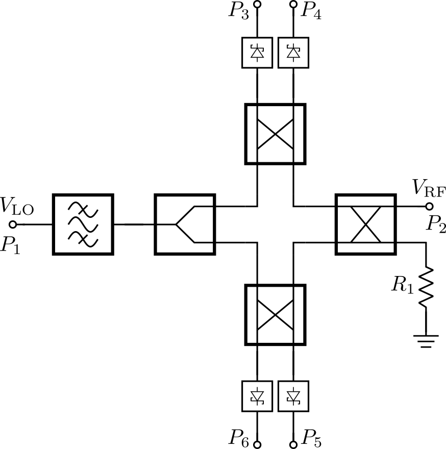

```python
import os
import shutil
import time
import urllib.request

# the runtime of the whole notebook is measured from here to the last cell
NOTEBOOK_START = time.time()
print(f"Notebook started at {time.strftime('%Y-%m-%d %H:%M:%S %Z')}")

# branch of the SPARX repository the assets (logos, block diagram, video) are taken from
SPARX_BRANCH = "next_release"
ASSET_URL    = f"https://raw.githubusercontent.com/iic-jku/SG13CMOS_SPARX/{SPARX_BRANCH}/sscs-ose-code-a-chip/assets"
ASSET_DIR    = "/tmp/assets"

# download the block diagram and the logo GDS files, the video is streamed below
shutil.rmtree(ASSET_DIR, ignore_errors=True)
os.makedirs(ASSET_DIR)
for asset in ["sparx_blockdiagram.png", "jku_logo_m5.gds", "IWS.gds", "D_Kellerer.gds", "supervisors.gds"]:
    urllib.request.urlretrieve(f"{ASSET_URL}/{asset}", f"{ASSET_DIR}/{asset}")

from IPython.display import Image, display
display(Image(filename=f"{ASSET_DIR}/sparx_blockdiagram.png", width=576))
```

# Video Demonstration

In the following video, the generation of six-port receivers from 60 GHz to 300 GHz in under one minute is demonstrated.

```python
from IPython.display import HTML, display

# the video is streamed from GitHub instead of embedded, which keeps the notebook small enough for Colab to render
video_url = f"{ASSET_URL}/sparx_gen_60ghz_to_300ghz.mp4"
display(HTML(
    f'<video src="{video_url}" width="1024" controls muted playsinline></video>'
    f'<p>If the video does not play, <a href="{video_url}" target="_blank">open it here</a>.</p>'
))
```

[video not shown]

If the video does not play, [open it here](https://raw.githubusercontent.com/iic-jku/SG13CMOS_SPARX/next_release/sscs-ose-code-a-chip/assets/sparx_gen_60ghz_to_300ghz.mp4).

# References

To understand the principle of six-port receivers and their architectures, it is recommended to read the following references:

- S. Dorrer, D. Kellerer-Pirklbauer, G. Zachl, and H. Pretl, "SPARX: An Open-Source, Automated, Programmatically Generated, Frequency-Scalable Six-Port Receiver in 130-nm CMOS," accepted for publication in the 2026 IEEE Nordic Circuits and Systems Conference (NorCAS), 2026. The design, the frequency scaling, and the verification of SPARX are described in this paper, which this notebook accompanies.
- A. Koelpin, G. Vinci, B. Laemmle, D. Kissinger and R. Weigel, "The Six-Port in Modern Society," in IEEE Microwave Magazine, vol. 11, no. 7, pp. 35-43, Dec. 2010, doi: 10.1109/MMM.2010.938584: https://ieeexplore.ieee.org/document/5590352
- T. Hentschel, "The six-port as a communications receiver," in IEEE Transactions on Microwave Theory and Techniques, vol. 53, no. 3, pp. 1039-1047, March 2005, doi: 10.1109/TMTT.2005.843507: https://ieeexplore.ieee.org/document/1406309
- M. Mailand, "System Analysis of Six-Port-Based RF-Receivers," in IEEE Transactions on Circuits and Systems I: Regular Papers, vol. 65, no. 1, pp. 319-330, Jan. 2018, doi: 10.1109/TCSI.2017.2734922: https://ieeexplore.ieee.org/document/8011483

# Requirements

To build this six-port receiver, the following tools and their respective dependencies are required:

- GDSFactory: https://github.com/gdsfactory/gdsfactory
- Updated IHP-Open-PDK GDSFactory version: https://github.com/iic-jku/IHP-GDSFactory-Addon
- IHP-Open-PDK: https://github.com/iic-jku/IHP-Open-PDK

The updated IHP-Open-PDK GDSFactory version contains all self-made RF devices and wraps existing PCells provided by the IHP-Open-PDK, allowing them to be used directly within the GDSFactory framework. We choose this approach because it requires very little maintenance. If IHP changes the layout of a cell, no wrapper update is necessary. Only interface changes to a PCell function require updates on our side.

> **Note:** This notebook demonstrates the layout generation of the six-port receiver, a top-level DRC, and the circuit simulation of the power detector and the receiver with VACASK, including the conversion of the EM results into a lumped-element netlist with snp2le. For the full design flow, refer to the [official SPARX GitHub repository](https://github.com/iic-jku/SG13CMOS_SPARX), which includes S-parameter simulation of the passive RF structures with AWS Palace, a complete LVS, DRC, and RCX verification flow using KLayout, Magic, and Netgen, and SBD-based power detector design in Xschem with ngspice and VACASK simulation. The entire flow is controlled by a Makefile. Simply install the IIC-OSIC-TOOLS container from JKU, clone the repository and run `make all` to build and verify the six-port receiver at 160 GHz, or `make build-layout FREQ=<GHz>` to generate it at another target frequency. The [SPARX documentation](https://iic-jku.github.io/SG13CMOS_SPARX/) describes the design, the flow, and every result in detail.

> **Running on Google Colab:** Open the notebook with the badge at the top and select *Runtime → Run all*. All tools are installed by the notebook itself, no local setup is required. If Colab asks to restart the session after the package installation, confirm and select *Runtime → Run all* again.

**Installation of IHP-Open-PDK GDSFactory version:**

First, our GDSFactory integration of the IHP-Open-PDK is cloned and installed. This IHP-Open-PDK version contains all self-made RF devices and wraps existing PCells provided by the IHP-Open-PDK, allowing them to be used directly within the GDSFactory framework. We choose this approach because it requires very little maintenance. If IHP changes the layout of a cell, no wrapper update is necessary. Only interface changes to a PCell function require updates on our side.

Running `pip install` on the cloned add-on installs the required Python dependencies automatically. The add-on and the IHP-Open-PDK are fetched at the commits this notebook was tested with, `IHP_COMMIT` and `PDK_COMMIT`. To use a newer version, replace the commit hash. The Python packages, among them GDSFactory, are pinned to the versions the notebook was tested with as well.

```python
PDK_ROOT = "/tmp/pdks"  # IHP-Open-PDK checkout
IHP_DIR  = "/tmp/ihp"   # IHP-Open-PDK GDSFactory add-on checkout

# the commits this notebook was tested with, of the add-on main branch and the IHP-Open-PDK dev branch
IHP_COMMIT = "4e5b2960f4b40507bb0ac54e8de3770517f291d3"
PDK_COMMIT = "6f788ad1f64130ced1d8849f5e4a84d7803576c8"

# the add-on reads PDK_ROOT to find the KLayout PCells of the IHP-Open-PDK
os.environ["PDK_ROOT"] = PDK_ROOT
os.environ["PDK"]      = "ihp-sg13g2"

! rm -rf {IHP_DIR} && git -c init.defaultBranch=main init -q {IHP_DIR}
! git -C {IHP_DIR} fetch -q --depth 1 https://github.com/iic-jku/IHP-GDSFactory-Addon.git {IHP_COMMIT} && git -C {IHP_DIR} checkout -q FETCH_HEAD
# the Python packages are pinned to the versions this notebook was tested with
%pip install -q {IHP_DIR} gdsfactory==9.51.0 kfactory==3.0.4 klayout==0.30.12 doroutes==0.5.0 scipy==1.18.1 "schemdraw[svgmath]==0.23" ziamath==0.13

# gdsfactory upgrades IPython, but the Colab kernel only starts with its preinstalled version, which is restored
import sys, IPython
if "google.colab" in sys.modules:
    %pip install -q ipython=={IPython.__version__}
```

[output not shown]

[output not shown]

[output not shown]

[output not shown]

[output not shown]

[output not shown]

[output not shown]

[output not shown]

[output not shown]

[output not shown]

[output not shown]

[output not shown]

[output not shown]

[output not shown]

[output not shown]

[output not shown]

[output not shown]

[output not shown]

[output not shown]

[output not shown]

[output not shown]

[output not shown]

[output not shown]

[output not shown]

[output not shown]

[output not shown]

[output not shown]

[output not shown]

[output not shown]

[output not shown]

[output not shown]

[output not shown]

[output not shown]

[output not shown]

**Installation of IHP-Open-PDK:**

Next, the IHP-Open-PDK itself is fetched at `PDK_COMMIT` of its `dev` branch and placed in the correct folder. The IHP-Open-PDK provides the technology files required for layout generation. Of its submodules, only the two that the KLayout PCells import are fetched.

```python
! rm -rf {PDK_ROOT} && git -c init.defaultBranch=main init -q {PDK_ROOT}
! git -C {PDK_ROOT} fetch -q --depth 1 https://github.com/iic-jku/IHP-Open-PDK.git {PDK_COMMIT} && git -C {PDK_ROOT} checkout -q FETCH_HEAD
! git -C {PDK_ROOT} submodule update -q --init --depth 1 \
    ihp-sg13g2/libs.tech/klayout/python/pycell4klayout-api \
    ihp-sg13g2/libs.tech/klayout/python/pypreprocessor
```

**Import of Python Modules:**

GDSFactory builds a layout as a hierarchy of Python objects. A `gf.Component` holds polygons, ports, and references to other components, and `connect()` places a reference so that one of its ports meets a port of another component, which is how every block of this chip is positioned. `ihp` is our GDSFactory add-on, and `ihp.PDK.activate()` makes the layers, cross sections, and cells of IHP SG13G2 the active PDK. The helper `snap_to_grid()` rounds a length down to the 5 nm manufacturing grid, so that computed dimensions such as $\lambda_g/4$ cannot produce off-grid geometry.

```python
import gdsfactory as gf
import ihp
from pathlib import Path
import scipy
from math import sqrt

ihp.PDK.activate()


def snap_to_grid(value: float) -> float:
    """Snap a length in um down to the nearest PDK grid point."""
    return round(value - value % ihp.tech.nm, 3)
```

**Design Constants:**

The device dimensions, routing widths, pad geometry, and layout spacings used throughout the notebook are collected here, identical to the constants of `scripts/six_port_gen.py` in the SPARX repository.

They are grouped by purpose: the MIM capacitor, transistor, and resistor dimensions of the power detector, the routing widths of its supply and signal nets, the probe pad geometry, the Metal5 no-fill zones around the pads, and the spacings that place the detectors, the pads, and the sealring. Unlike the RF devices, these dimensions are fixed and do not scale with `f`.

```python
# CMIM capacitor dimensions (um)
CMIM_SIZE = 10  # width and length of standard CMIM cap
CMIM_PITCH = 11.2  # center-to-center pitch in cap arrays
CMIM_SPACING_TM1 = 0.52  # min TM1 spacing between caps (design rule 5.17)
CMIM_FILL_WIDTH = 6.8  # fill capacitor width
CMIM_FILL_LENGTH = 9  # fill capacitor length
CAP_BUS_WIDTH = 4  # metal bus width connecting cap plates

# MOSFET output stage parameters
NUM_GATES = 24  # total gate fingers per transistor (incl. dummies)
NMOS_WIDTH = 60  # nmos finger width (um)
PMOS_WIDTH = 120  # pmos finger width (um)
GATE_LENGTH = 0.13  # drawn gate length (um)
GUARD_RING_DISTANCE = 2  # guard ring distance (um)
GATE_EXTENSION_NMOS = 2.15  # gate poly extension for nmos via connection
GATE_EXTENSION_PMOS = 3.55  # gate poly extension for pmos via connection
NMOS_PMOS_SPACING = 15  # vertical gap between nmos and pmos drain vias

# Resistor dimensions (um)
RSIL_WIDTH = 0.5  # rsil resistor width (XR1, XR5, termination)
RSIL_LENGTH = 2.5  # rsil resistor length
RPPD_WIDTH = 0.5  # rppd resistor width (XR2, XR4)
RPPD_LENGTH = 1.5  # rppd resistor length
RHIGH_WIDTH = 0.5  # rhigh resistor width (XR3)
RHIGH_LENGTH = 2  # rhigh resistor length

# Routing widths (um)
ROUTE_WIDTH_VDD = 8  # VDD power bus (TM1)
ROUTE_WIDTH_VSS = 2  # VSS ground bus (M5)
ROUTE_WIDTH_SIGNAL = 4  # signal lines to probe pads (M3/M4)
ROUTE_WIDTH_MIN_M1 = 0.26  # minimum Metal1 route width
ROUTE_WIDTH_BIAS = 0.5  # bias network routing
ROUTE_WIDTH_BIAS_M1 = 0.46  # bias Metal1 routing
ROUTE_WIDTH_GATE = 0.6  # gate connection routing (M2/M3)
ROUTE_WIDTH_REPLICA = 0.61  # replica circuit drain routing
ROUTE_WIDTH_SBD_SUB = 5.7  # Schottky diode substrate connection
ROUTE_WIDTH_SBD_GUARD = 0.3  # SBD D1-D2 guard ring connection
ROUTE_MIN_STRAIGHT = 10  # minimum straight length to avoid self-routing

# Probe pad parameters (um)
PROBE_PITCH = 125  # probe pad pitch
PROBE_GROUND_WIDTH = 120  # ground pad width (left probe)
PROBE_GROUND_WIDTH_RIGHT = 125  # ground pad width (right probe)
PROBE_SIGNAL_SIZE = 65  # signal pad width and length

# Nofill exclusion zones (um)
NOFILL_GSG_SIZE = 105  # nofill square around GSG probes
NOFILL_VDD_SIZE = 110  # nofill square around VDD pads
NOFILL_SIDE_WIDTH = 235  # side nofill width (85 + pitch + 25)
NOFILL_SIDE_OFFSET = 12.5  # side nofill centering offset ((110 - 85) / 2)

# Layout spacing (um)
RFIN_GAP = 40  # gap between BLC port and PD rfin
RFIN_PD = 18.4 # part of the connection that is part of the PD
PROBE_PD_GAP = 5  # gap between PD edge and probe edge
SEALRING_MARGIN = 50  # margin around circuit for sealring

# Six-port network geometry
CORNER_Z_FACTOR = 1.314  # impedance scaling for tline corners
CONNECTION_LEN_TERM = 30  # termination connection (before freq_scale, um)
CONNECTION_LEN_BPF_PAD = 30  # BPF-to-pad connection (before freq_scale, um)
CONNECTION_LEN_BLC_PAD = 40  # BLC-to-pad connection (before freq_scale, um)
CONNECTION_LEN_BLC_EXTRA = 25  # extra pad clearance added to BLC-to-pad (um)

# Logo placement
LOGO_VERTICAL_CLEARANCE = 20  # minimal vertical clearance between logo and probe pads
```

# Power Detector Design based on Schottky Barrier Diodes

**Circuit Operation:**

- **R1** provides a 52 Ω input termination.
- **C1** ac-couples the RF + LO signal to the demodulating SBD **D1** and is implemented as a MIM capacitor.
- **M3 (= 10 M1) – M4 (= 10 M2)** and **R2** form a transimpedance amplifier (TIA) that delivers a buffered voltage output.
- **M1–M2**, **D2 (= D1)**, and **R4 (= R2) – R5 (= R1)** implement a replica bias. With this replica circuit, it is now possible to measure the demodulated output signal differentially.
- **C2-C4** are MIM capacitor arrays that provide proper decoupling of the supply rail and bias voltages (not shown in the schematic).

**Layout Considerations:**

- Minimize RF input parasitics (R, L, C):
  - Route TopMetal2 directly down to the top plate (TopMetal1) of C1 with a VIA.
  - Use a VIA-stack from the bottom plate (Metal5) of C1 directly down to the SBD.
- Apply **Metal5 no-fill regions** to reduce parasitic capacitance.
- Match components of the main and replica paths.
- **C2–C4** values may be adapted to layout requirements, provided they remain large enough for sufficient supply-rail decoupling.

> In the following code block, the SBD-based power detector (PD) is defined as a standalone `@gf.cell` function. This modular approach enables the same detector design to be reused across all four output channels.

**Schematic of the power detector:**

The following cell draws the schematic with `schemdraw`. The voltages at the nodes are the simulated DC operating point, and the currents at the bottom are the bias currents of the main branch (4 mA) and the replica branch (400 µA). Every replica device carries the label of the main device it copies, and the main transistors are labeled $10\,M_1$ and $10\,M_2$ because they are ten times the size of the replica transistors $M_1$ and $M_2$.

```python
# Drawing of SBD-based Power Detector
import matplotlib
matplotlib.rcParams.update({
    "mathtext.fontset": "cm",
    "font.family": "serif",
})
import schemdraw as sd
import schemdraw.elements as elm
sd.svgconfig.svg2 = False

with sd.Drawing() as d:
    d.config(unit=2, fontsize=16)

    # Vrf Input, C1, D1
    Vrf = elm.Dot(open=True).label(r'$V_\mathrm{rf}$', loc='left', ofst=0.15)
    elm.Line().right().length(1.0)
    C1 = elm.Capacitor().right().label(r'$C_\mathrm{1}$', loc='top', ofst=0.15)
    elm.Line().right().length(1.0)
    node_rfin_int = elm.Dot().label(r'$1.128\,\mathrm{V}$', loc='bottom', ofst=0.15)
    elm.Line().right().length(1.0)
    D1 = elm.Schottky().right().label(r'$D_\mathrm{1}$', loc='top', ofst=0.15)
    elm.Line().right().length(1.0)
    node_bb_int = elm.Dot().label(r'$0.756\,\mathrm{V}$', loc='bottom', ofst=(-0.75, -0.15))

    # R1, R3, VDD
    elm.Line().at(node_rfin_int.end).up().length(1.0)
    R1 = elm.Resistor().up().label(r'$R_\mathrm{1}$', loc='top', ofst=0.15)
    node_bias1 = elm.Line().up().length(1.0).dot().label(r'$1.129\,\mathrm{V}$', loc='right', ofst=0.15)
    elm.Line().left().length(0.5)
    R3 = elm.Resistor().left().label(r'$R_\mathrm{3}$', loc='top', ofst=0.15)
    elm.Line().left().length(0.5)
    node_vdd = elm.Line().up().length(1.5).dot()
    elm.Dot().label(r'$1.5\,\mathrm{V}$', loc='top', ofst=0.15)
    elm.Line().left().tox(Vrf.start)
    vdd = elm.Dot(open=True).label(r'$V_\mathrm{DD}$', loc='left', ofst=0.15)

    # M3, M4, R2, VSS
    elm.Line().at(node_bb_int.end).right().length(0.5)
    R2 = elm.Resistor().right().label(r'$R_\mathrm{2}$', loc='top', ofst=0.15)
    elm.Line().right().length(0.5)
    node_vout = elm.Dot().label(r'$0.730\,\mathrm{V}$', loc='bottom', ofst=(0.85, -0.15))
    elm.Line().down().length(1.0)
    M3 = elm.AnalogNFet(offset_gate=False).anchor('drain').theta(0).label(r'$10\,M_\mathrm{1}$', loc='right', ofst=0.15).reverse()
    elm.Line().at(M3.source).down().length(1.0)
    elm.Dot().label(r'$4\,\mathrm{mA}$', loc='bottom', ofst=0.15)
    elm.Line().left().tox(Vrf.start)
    vss = elm.Dot(open=True).label(r'$V_\mathrm{SS}$', loc='left', ofst=0.15)
    elm.Line().at(M3.gate).left().tox(node_bb_int.end)
    elm.Line().up().toy(node_bb_int.end)
    elm.Line().at(node_vout.end).up().length(1.0)
    M4 = elm.AnalogPFet(offset_gate=False).anchor('drain').theta(0).label(r'$10\,M_\mathrm{2}$', loc='right', ofst=0.15).reverse()
    elm.Line().at(M4.source).up().toy(node_vdd.end).dot()
    elm.Line().left().tox(node_vdd.end)
    elm.Line().at(M4.gate).left().tox(node_bb_int.end)
    elm.Line().down().toy(node_bb_int.end)
    elm.Line().at(node_vout.end).right().length(2.0)
    Vout = elm.Dot(open=True).label(r'$V_\mathrm{out}$', loc='right', ofst=0.15)

    # Replica Circuit: R5, D2, R4, M1, M2
    elm.Line().at(node_bias1.end).right().length(21.0)
    elm.Line().down().length(1.0)
    R5 = elm.Resistor().down().label(r'$R_\mathrm{1}$', loc='top', ofst=0.15)
    elm.Line().down().length(1.0)
    elm.Line().left().length(1.0)
    D2 = elm.Schottky().left().label(r'$D_\mathrm{1}$', loc='top', ofst=0.15)
    elm.Line().left().length(1.0)
    node_bias2 = elm.Dot().label(r'$0.761\,\mathrm{V}$', loc='bottom', ofst=(0.85, -0.15))
    elm.Line().at(node_bias2.end).left().length(0.5)
    R4 = elm.Resistor().left().label(r'$R_\mathrm{2}$', loc='top', ofst=0.15)
    elm.Line().left().length(0.5)
    node_vref = elm.Dot().label(r'$0.737\,\mathrm{V}$', loc='bottom', ofst=(-0.75, -0.15))
    elm.Line().down().length(1.0)
    M1 = elm.AnalogNFet(offset_gate=False).anchor('drain').theta(0).label(r'$M_\mathrm{1}$', loc='left', ofst=0.15)
    elm.Line().at(M1.source).down().toy(vss.end).label(r'$400\,\mu\mathrm{A}$', loc='left', ofst=0.15)
    elm.Line().left().tox(node_vout.end)
    elm.Line().at(M1.gate).right().tox(node_bias2.end)
    elm.Line().up().toy(node_bias2.end)
    elm.Line().at(node_vref.end).up().length(1.0)
    M2 = elm.AnalogPFet(offset_gate=False).anchor('drain').theta(0).label(r'$M_\mathrm{2}$', loc='left', ofst=0.15)
    elm.Line().at(M2.source).up().toy(node_vdd.end)
    elm.Line().left().tox(node_vout.end)
    elm.Line().at(M2.gate).right().tox(node_bias2.end)
    elm.Line().down().toy(node_bias2.end)
    elm.Line().at(node_vref.end).left().length(2.0)
    Vref = elm.Dot(open=True).label(r'$V_\mathrm{ref}$', loc='left', ofst=0.15)
```

[figure not shown]

**Layout of the power detector:**

```python
@gf.cell
def powdet_sbd() -> gf.Component:
    """Schottky-diode power detector with transimpedance amplifier.

    Ports: rfin (TM2), vout (M4), vref (M4), vss (M5), vdd (TM1).
    """
    c = gf.Component("powdet_sbd")

    # via from rfin on TM2 to C1 on TM1
    via_tm1_tm2 = ihp.cells.via_stack(
        top_layer="TopMetal2",
        bottom_layer="TopMetal1",
        vt2_columns=4,
        vt2_rows=3,
    )

    via_tm1_tm2.ports["bottom"].orientation = 0
    via_tm1_tm2_ref = c.add_ref(via_tm1_tm2)
    # reference cmim capacitor and connect to via
    cmim = ihp.cells.cmim(width=CMIM_SIZE, length=CMIM_SIZE)
    c1_ref = c.add_ref(cmim)
    c1_ref.connect("T", via_tm1_tm2_ref.ports["bottom"], allow_width_mismatch=True)


    # via cell from Metal2 to Metal5
    via_m2_m5 = ihp.cells.via_stack(
        top_layer="Metal5",
        bottom_layer="Metal2",
        vn_columns=6,
        vn_rows=3,
    )

    # via from CMIM C1 to XQ1
    via_m2_m5.ports["top"].orientation = 0
    via_m2_m5_ref = c.add_ref(via_m2_m5)
    via_m2_m5_ref.connect("top", c1_ref.ports["B"], allow_width_mismatch=True)

    # create D1 and connect to rfin via C1 and the vias
    schottky = ihp.cells.schottky()
    schottky.locked = False
    schottky.add_label(text="schottky_nbl1", layer=ihp.tech.LAYER.TEXTdrawing)

    d1_ref = c.add_ref(schottky)
    d1_ref.connect("e4", via_m2_m5_ref.ports["bottom"], allow_width_mismatch=True, allow_layer_mismatch=True)

    # Create D2 nearby D1 for better matching
    d2_ref = c.add_ref(schottky)
    d2_ref.ymin = d1_ref.ymin
    d2_ref.xmin = d1_ref.xmax  # min spacing according to design rules 5.10

    # Create capacitor array for c2
    c2 = gf.Component("C2")
    cmim = ihp.cells.cmim(width=CMIM_SIZE, length=CMIM_SIZE)
    cap_connection_thickness = CAP_BUS_WIDTH  # thickness of the metal connection between caps
    # create 3 * 4 array of cmim capacitors with column pitch of 0.52 + 11.2 to fit the required spacing for TM1 and the size of the caps
    # with one missing cap to fit C1 in there
    spacing_between_caps = CMIM_SPACING_TM1
    top_row = c2.add_ref(
        gf.components.array(component=cmim, columns=6, rows=1, column_pitch=spacing_between_caps + CMIM_PITCH)
    )

    middle_row = c2.add_ref(
        gf.components.array(component=cmim, columns=6, rows=1, column_pitch=spacing_between_caps + CMIM_PITCH)
    )
    bottom_row = c2.add_ref(
        gf.components.array(
            component=cmim,
            columns=6,
            rows=3,
            column_pitch=spacing_between_caps + CMIM_PITCH,
            row_pitch=-(spacing_between_caps + CMIM_PITCH),
        )
    )
    top_row.ymin = middle_row.ymax + spacing_between_caps  # min spacing according to design rules 5.17
    bottom_row.ymax = middle_row.ymin - spacing_between_caps  # min spacing according to design rules 5.17
    c2.add_ports(top_row.ports, prefix="TR_")
    c2.add_ports(middle_row.ports, prefix="MR_")
    c2.add_ports(bottom_row.ports, prefix="BR_")


    # Orient outermost ports inward for horizontal cap-to-cap connection
    for prefix in [
        "TR_T_1_",
        "TR_B_1_",
        "MR_T_1_",
        "MR_B_1_",
        "BR_T_1_",
        "BR_B_1_",
        "BR_T_2_",
        "BR_B_2_",
        "BR_T_3_",
        "BR_B_3_",
    ]:
        c2.ports[f"{prefix}1"].orientation = 0
        c2.ports[f"{prefix}6"].orientation = 180

    c2_connection_t = gf.routing.route_bundle_electrical(
        component=c2,
        ports1=[
            c2.ports["TR_T_1_1"],
            c2.ports["BR_T_2_1"],
            c2.ports["BR_T_3_1"],
            c2.ports["MR_T_1_1"],
            c2.ports["BR_T_1_1"],
        ],
        ports2=[
            c2.ports["TR_T_1_6"],
            c2.ports["BR_T_2_6"],
            c2.ports["BR_T_3_6"],
            c2.ports["MR_T_1_6"],
            c2.ports["BR_T_1_6"],
        ],
        route_width=cap_connection_thickness,
        layer=ihp.tech.LAYER.TopMetal1drawing,
        allow_layer_mismatch=True,
        allow_width_mismatch=True,
        auto_taper=False,
        separation=0,
    )

    c2_connection_b = gf.routing.route_bundle_electrical(
        component=c2,
        ports1=[
            c2.ports["TR_B_1_1"],
            c2.ports["BR_B_2_1"],
            c2.ports["BR_B_3_1"],
            c2.ports["MR_B_1_1"],
            c2.ports["BR_B_1_1"],
        ],
        ports2=[
            c2.ports["TR_B_1_6"],
            c2.ports["BR_B_2_6"],
            c2.ports["BR_B_3_6"],
            c2.ports["MR_B_1_6"],
            c2.ports["BR_B_1_6"],
        ],
        route_width=cap_connection_thickness,
        layer=ihp.tech.LAYER.Metal5drawing,
        allow_layer_mismatch=True,
        allow_width_mismatch=True,
        auto_taper=False,
        separation=0,
    )

    # orient top row ports to face downwards to connect to bottom row ports
    ihp.cells.utils.change_port_orientation(
        c2, ["TR_T_1_1", "TR_T_1_2", "TR_T_1_3", "TR_T_1_4", "TR_T_1_5", "TR_T_1_6"], 270
    )
    ihp.cells.utils.change_port_orientation(
        c2, ["TR_B_1_1", "TR_B_1_2", "TR_B_1_3", "TR_B_1_4", "TR_B_1_5", "TR_B_1_6"], 270
    )

    # orient bottom row ports to face downwards to connect to top row ports
    ihp.cells.utils.change_port_orientation(
        c2, ["BR_T_3_1", "BR_T_3_2", "BR_T_3_3", "BR_T_3_4", "BR_T_3_5", "BR_T_3_6"], 90
    )
    ihp.cells.utils.change_port_orientation(
        c2, ["BR_B_3_1", "BR_B_3_2", "BR_B_3_3", "BR_B_3_4", "BR_B_3_5", "BR_B_3_6"], 90
    )

    c2_connection_top = gf.routing.route_bundle_electrical(
        component=c2,
        ports1=[
            c2.ports["BR_T_3_1"],
            c2.ports["BR_T_3_2"],
            c2.ports["BR_T_3_3"],
            c2.ports["BR_T_3_4"],
            c2.ports["BR_T_3_5"],
            c2.ports["BR_T_3_6"],
        ],
        ports2=[
            c2.ports["TR_T_1_1"],
            c2.ports["TR_T_1_2"],
            c2.ports["TR_T_1_3"],
            c2.ports["TR_T_1_4"],
            c2.ports["TR_T_1_5"],
            c2.ports["TR_T_1_6"],
        ],
        route_width=cap_connection_thickness,  # adjust for thicker connections
        layer=ihp.tech.LAYER.TopMetal1drawing,
        allow_layer_mismatch=True,
        allow_width_mismatch=True,
        auto_taper=False,
        separation=0,
    )
```

```python
    c2_connection_bottom = gf.routing.route_bundle_electrical(
        component=c2,
        ports1=[
            c2.ports["BR_B_3_1"],
            c2.ports["BR_B_3_2"],
            c2.ports["BR_B_3_3"],
            c2.ports["BR_B_3_4"],
            c2.ports["BR_B_3_5"],
            c2.ports["BR_B_3_6"],
        ],
        ports2=[
            c2.ports["TR_B_1_1"],
            c2.ports["TR_B_1_2"],
            c2.ports["TR_B_1_3"],
            c2.ports["TR_B_1_4"],
            c2.ports["TR_B_1_5"],
            c2.ports["TR_B_1_6"],
        ],
        route_width=cap_connection_thickness,  # adjust for thicker connections
        layer=ihp.tech.LAYER.Metal5drawing,
        allow_layer_mismatch=True,
        allow_width_mismatch=True,
        auto_taper=False,
        separation=0,
    )

    # orient top row ports to face upwards to connect the ground plates to the other caps
    ihp.cells.utils.change_port_orientation(c2, ["TR_B_1_1", "TR_B_1_2", "TR_B_1_3", "TR_B_1_6"], 90)
    ihp.cells.utils.change_port_orientation(c2, ["TR_T_1_6"], 0)  # for connection to bias1
    ihp.cells.utils.change_port_orientation(c2, ["BR_B_3_4", "BR_B_3_5"], 270)

    c2_ref = c.add_ref(c2)
    c2_ref.rotate(-90)
    c2_ref.center = c1_ref.center
    c2_ref.ymin = c1_ref.ymax + 10
    c2_ref.xmax = c1_ref.xmax + c1_ref.xsize + CMIM_SPACING_TM1

    ## end of c2 generation

    r_sil = ihp.cells.rsil(width=RSIL_WIDTH, length=RSIL_LENGTH)

    # let the ports of xr1 and xr5 face each other for easier routing
    r_sil.ports["e2"].orientation = 0
    xr1_ref = c.add_ref(r_sil.copy())

    r_sil.ports["e2"].orientation = 180
    xr5 = r_sil.copy()
    xr5_ref = c.add_ref(xr5)

    # spacing between D1 and xr1/xr5
    spacing = 1
    xr1_ref.xmax = d1_ref.xmax - 1.88
    xr1_ref.ymax = d1_ref.ymin - spacing

    xr5_ref.xmin = d2_ref.xmin + 1.88
    xr5_ref.ymin = xr1_ref.ymin

    route_xr1_xr5 = gf.routing.route_bundle_electrical(
        component=c,
        ports1=[xr1_ref.ports["e2"]],
        ports2=[xr5_ref.ports["e2"]],
        route_width=ROUTE_WIDTH_MIN_M1,
        layer=ihp.tech.LAYER.Metal1drawing,
        allow_layer_mismatch=True,
        allow_width_mismatch=True,
        auto_taper=False,
        separation=0,
    )

    # via for connection D1 to xr1 and xr5 to D2
    via_m1_m2 = ihp.cells.via_stack(
        top_layer="Metal2",
        bottom_layer="Metal1",
        vn_columns=6,
        vn_rows=2,
    )

    # via D1 -> xr1
    via_m1_m2.ports["top"].orientation = 90
    via_m1_m2.ports["bottom"].orientation = 0
    via_m1_m2_ref = c.add_ref(via_m1_m2.copy())
    via_m1_m2_ref.center = d1_ref.center
    via_m1_m2_ref.ymax = d1_ref.ymin

    # route from D1 to via
    route = gf.routing.route_bundle_electrical(
        component=c,
        ports1=[d1_ref.ports["e4"]],
        ports2=[via_m1_m2_ref.ports["top"]],
        route_width=max(via_m1_m2_ref.xsize, via_m1_m2_ref.ysize),
        layer=ihp.tech.LAYER.Metal2drawing,
        allow_layer_mismatch=True,
        allow_width_mismatch=True,
        auto_taper=False,
        separation=0,
    )

    # route from via to xr1
    route = gf.routing.route_bundle_electrical(
        component=c,
        ports1=[via_m1_m2_ref.ports["bottom"]],
        ports2=[xr1_ref.ports["e1"]],
        route_width=min(via_m1_m2_ref.xsize, via_m1_m2_ref.ysize),
        layer=ihp.tech.LAYER.Metal1drawing,
        allow_layer_mismatch=True,
        allow_width_mismatch=True,
        auto_taper=False,
        separation=0,
    )

    # connect second diode to input resistors
    # via D2 -> xr5
    via_m1_m2.ports["top"].orientation = 90
    via_m1_m2.ports["bottom"].orientation = 180
    via_m1_m2_ref = c.add_ref(via_m1_m2.copy())
    via_m1_m2_ref.center = d2_ref.center
    via_m1_m2_ref.ymax = d2_ref.ymin

    # route from D2 to via
    route = gf.routing.route_bundle_electrical(
        component=c,
        ports1=[d2_ref.ports["e4"]],
        ports2=[via_m1_m2_ref.ports["top"]],
        route_width=max(via_m1_m2_ref.xsize, via_m1_m2_ref.ysize),
        layer=ihp.tech.LAYER.Metal2drawing,
        allow_layer_mismatch=True,
        allow_width_mismatch=True,
        auto_taper=False,
        separation=0,
    )

    # route from via to xr5
    route = gf.routing.route_bundle_electrical(
        component=c,
        ports1=[via_m1_m2_ref.ports["bottom"]],
        ports2=[xr5_ref.ports["e1"]],
        route_width=min(via_m1_m2_ref.xsize, via_m1_m2_ref.ysize),
        layer=ihp.tech.LAYER.Metal1drawing,
        allow_layer_mismatch=True,
        allow_width_mismatch=True,
        auto_taper=False,
        separation=0,
    )

    ## Build transimpedance amplifier with Schottky diode as input device.
    # M1 (nmos, 20 gates) + M3 (nmos, 2 gates) + 2 dummy gates = 24
    # M2 (pmos, 20 gates) + M4 (pmos, 2 gates) + 2 dummy gates = 24
    ng_mos = NUM_GATES
    width_nmos = NMOS_WIDTH  # um
    width_pmos = PMOS_WIDTH  # um

    c_output = gf.Component("output_stage")

    m1_3 = ihp.cells.nmos(
        w=width_nmos,
        l=GATE_LENGTH,
        ng=ng_mos,
        guardRingType="psub",
        guardRingDistance=GUARD_RING_DISTANCE,
    )

    via_gat_m1 = ihp.cells.via_stack(
        top_layer="Metal1",
        bottom_layer="GatPoly",
        vn_columns=1,
        vn_rows=2,
    )

    via_gat_m2 = ihp.cells.via_stack(
        top_layer="Metal2",
        bottom_layer="GatPoly",
        vn_columns=1,
        vn_rows=3,
    )

    via_gat_m3 = ihp.cells.via_stack(
        top_layer="Metal3",
        bottom_layer="GatPoly",
        vn_columns=1,
        vn_rows=3,
    )

    m1_3.locked = False
    via_gat_m1.ports["bottom"].orientation = 90
    via_gat_m2.ports["bottom"].orientation = 90
    via_gat_m3.ports["bottom"].orientation = 90
    via_gat_m3.ports["top"].orientation = 270  # turn top port for later connection
    gate_ports = m1_3.get_ports_list(layer=ihp.tech.LAYER.GatPolydrawing)
    gate_ports.sort(key=lambda p: p.center[0])  # left to right, so list indices match the G_ numbering
    gate_straight = ihp.cells.straight(
        length=GATE_EXTENSION_NMOS, cross_section="gatpoly_routing", width=GATE_LENGTH  # gate poly width
    )
    gate_via_refs_nmos = []
    for i, p in enumerate(gate_ports):
        if p.name in ["G_1", "G_24"]:  # these gates will be connected to metal1
            gate_via_refs_nmos.append(m1_3.add_ref(via_gat_m2))
        elif p.name in ["G_12", "G_13"]:  # these gates will be connected to metal2
            gate_via_refs_nmos.append(m1_3.add_ref(via_gat_m2))
        else:  # all others to metal3
            gate_via_refs_nmos.append(m1_3.add_ref(via_gat_m3))
        gate_straight_ref = m1_3.add_ref(gate_straight)
        gate_straight_ref.connect("e1", m1_3.ports[p.name], allow_width_mismatch=True, allow_layer_mismatch=True)
        via_gat_m2_ref = gate_via_refs_nmos[-1]
        via_gat_m2_ref.connect(
            "bottom", gate_straight_ref.ports["e2"], allow_width_mismatch=True, allow_layer_mismatch=True
        )
```

```python
    # connect gates 1 and 24 with metal1 to ground
    via_gat_m2.ports["top"].orientation = 0
    start_point = gate_via_refs_nmos[23].ports["top"].center[0]  # G_24's via
    end_point = m1_3.ports["DS_29"].center[0]  # right guard-ring tap
    straight_ref = m1_3.add_ref(
        ihp.cells.straight(
            length=abs(end_point - start_point),
            cross_section="metal2_routing",
            width=1.11,  # manual measure of the height of the via
        )
    )
    straight_ref.connect("e1", gate_via_refs_nmos[23].ports["top"], allow_width_mismatch=True, allow_layer_mismatch=True)
    via_m1_m2 = ihp.cells.via_stack(
        top_layer="Metal2",
        bottom_layer="Metal1",
        vn_columns=3,
        vn_rows=1,
    )
    via_m1_m2_ref = m1_3.add_ref(via_m1_m2)
    via_m1_m2_ref.connect("top", straight_ref.ports["e2"], allow_width_mismatch=True, allow_layer_mismatch=True)

    via_gat_m2.ports["top"].orientation = 180
    straight_ref = m1_3.add_ref(
        ihp.cells.straight(
            length=abs(end_point - start_point),
            cross_section="metal2_routing",
            width=1.11,  # manual measure of the height of the via
        )
    )
    straight_ref.connect(
        "e1", gate_via_refs_nmos[0].ports["top"], allow_width_mismatch=True, allow_layer_mismatch=True
    )
    via_m1_m2_ref = m1_3.add_ref(via_m1_m2)
    via_m1_m2_ref.connect("top", straight_ref.ports["e2"], allow_width_mismatch=True, allow_layer_mismatch=True)

    # connect Gates 2-11 and 14-23 (all 20 gates) together with metal3
    start_point = m1_3.ports["G_2"].center
    end_point = m1_3.ports["G_23"].center
    straight_ref = m1_3.add_ref(
        ihp.cells.straight(
            length=abs(end_point[0] - start_point[0]),
            cross_section="metal3_routing",
            width=max(
                gate_via_refs_nmos[1].xsize, gate_via_refs_nmos[1].ysize
            ),  # manual measure of the height of the via
        )
    )
    straight_ref.center = (
        (start_point[0] + end_point[0]) / 2,
        gate_via_refs_nmos[1].center[1],
    )  # align with the via of the first M1 gate

    # connect Gates 12-13 (2 gates) together with metal2
    start_point = m1_3.ports["G_12"].center
    end_point = m1_3.ports["G_13"].center
    straight_ref = m1_3.add_ref(
        ihp.cells.straight(
            length=abs(end_point[0] - start_point[0]),
            cross_section="metal2_routing",
            width=0.6,  # manual measure of the height of the via
        )
    )
    straight_ref.center = (
        (start_point[0] + end_point[0]) / 2,
        gate_via_refs_nmos[11].center[1],
    )  # align with the via of the first M3 gate

    # connect source to GND
    # Source and drain fingers by their deterministic left-to-right port names
    # (DS_ ports are renumbered by position in the IHP PDK, so these lists are
    # stable across tool versions). DS_15 is the center column that also holds
    # the shortened drain via stack.
    m1_3_source_ports = [m1_3.ports[f"DS_{i}"] for i in (2, 3, 5, 7, 9, 11, 13, 17, 19, 21, 23, 25, 27, 28)]
    m1_3_drain_ports = [m1_3.ports[f"DS_{i}"] for i in (4, 6, 8, 10, 12, 15, 18, 20, 22, 24, 26)]

    # source ground connection
    source_straight = ihp.cells.straight(
        length=3.28,  # source finger to the center of the top guardring segment
        # (was |DS_1.y - DS_27.y| under the old port enumeration; those
        # guard-rail pin ports are no longer emitted as ports)
        cross_section="metal2_routing",
        width=0.26,  # manual measure of the height of the via
    )
    via_m1_m2 = ihp.cells.via_stack(
        top_layer="Metal2",
        bottom_layer="Metal1",
        vn_columns=7,
        vn_rows=1,
    )
    via_m1_m2.ports["bottom"].orientation = 0
    via_m1_m2.ports["top"].orientation = 180
    for p in m1_3_source_ports:
        p.orientation = 90  # orient ports to face the top
        via_m1_m2_ref = m1_3.add_ref(via_m1_m2)
        via_m1_m2_ref.connect("bottom", p, allow_width_mismatch=True, allow_layer_mismatch=True)
        source_straight_ref = m1_3.add_ref(source_straight)
        source_straight_ref.connect(
            "e1", via_m1_m2_ref.ports["top"], allow_width_mismatch=True, allow_layer_mismatch=True
        )

    # connect drains to M3
    via_m1_m4 = ihp.cells.via_stack(
        top_layer="Metal4",
        bottom_layer="Metal1",
        vn_columns=1,
        vn_rows=7,
    )

    drain_via_refs_nmos = []
    for p in m1_3_drain_ports:
        p.orientation = 90  # orient ports to face the top
        if p.name in ["DS_15"]:  # center drain column (x = 6.27), gets the shortened stack
            via_m1_m4_short = ihp.cells.via_stack(
                top_layer="Metal4",
                bottom_layer="Metal1",
                vn_columns=1,
                vn_rows=3,
            )
            via_m1_m4_short.ports["top"].orientation = 270
            drain_via_refs_nmos.append(m1_3.add_ref(via_m1_m4_short))
            drain_via_refs_nmos[-1].center = p.center
            drain_via_refs_nmos[-1].ymax = p.center[1] - 0.245  # manual measurement to align with metal1 below
        else:
            via_m1_m4.ports["bottom"].orientation = 90
            via_m1_m4.ports["top"].orientation = 90
            via_m1_m4_ref = m1_3.add_ref(via_m1_m4)
            via_m1_m4_ref.connect("bottom", p, allow_width_mismatch=True, allow_layer_mismatch=True)
            drain_via_refs_nmos.append(via_m1_m4_ref)

    # horizontal drain connection for nmos
    straight_drain_connection = ihp.cells.straight(
        length=abs(
            drain_via_refs_nmos[0].center[0] - drain_via_refs_nmos[-1].center[0]
        ),  # span from the first to the last drain via
        cross_section="metal4_routing",
        width=2,  # manual measure of the height of the via
    )
    straight_drain_connection_ref = m1_3.add_ref(straight_drain_connection)
    straight_drain_connection_ref.xmin = drain_via_refs_nmos[0].center[0]  # leftmost drain via
    straight_drain_connection_ref.ymin = drain_via_refs_nmos[0].center[1]
```

```python
    m1_3.add_ports(gate_via_refs_nmos[6].ports, prefix="gate_M1_")  # G_7's via
    m1_3.ports["DS_16"].orientation = 90  # so the top-level vdd via stack connects unrotated
    m1_3.add_port(name="drain_connection_M1", port=drain_via_refs_nmos[8].ports["top"])  # DS_22 column (x = 9.33)
    m1_3.add_port(name="drain_connection_M3", port=drain_via_refs_nmos[5].ports["top"])
    m1_3.add_port(
        name="gate_connection_M3",
        center=(
            (gate_via_refs_nmos[11].center[0] + gate_via_refs_nmos[12].center[0]) / 2,
            gate_via_refs_nmos[11].center[1],
        ),
        cross_section="metal2_routing",
        orientation=270,
        port_type="electrical",
    )
    m1_3_ref = c_output.add_ref(m1_3)
    m1_3_ref.move((0, 30))

    m2_4 = ihp.cells.pmos(
        w=width_pmos,
        l=GATE_LENGTH,
        ng=ng_mos,
        guardRingType="nwell",
        guardRingDistance=GUARD_RING_DISTANCE,
    )

    # connect gates of M2 and M4 together

    m2_4.locked = False
    gate_ports = m2_4.get_ports_list(layer=ihp.tech.LAYER.GatPolydrawing)
    gate_ports.sort(key=lambda p: p.center[0])  # left to right, so list indices match the G_ numbering
    gate_straight = ihp.cells.straight(
        length=GATE_EXTENSION_PMOS, cross_section="gatpoly_routing", width=GATE_LENGTH  # gate poly width
    )
    gate_via_refs_pmos = []
    for i, p in enumerate(gate_ports):
        p.orientation += 180  # orient gates to face downwards for easier connection to nmos gates
        if p.name in ["G_1", "G_24"]:  # these gates will be connected to metal1
            gate_via_refs_pmos.append(m2_4.add_ref(via_gat_m2))
        elif p.name in ["G_12", "G_13"]:  # these gates will be connected to metal2
            gate_via_refs_pmos.append(m2_4.add_ref(via_gat_m2))
        else:  # all others to metal3
            gate_via_refs_pmos.append(m2_4.add_ref(via_gat_m3))
        gate_straight_ref = m2_4.add_ref(gate_straight)
        gate_straight_ref.connect("e1", m2_4.ports[p.name], allow_width_mismatch=True, allow_layer_mismatch=True)
        gate_via_refs_pmos[-1].connect(
            "bottom", gate_straight_ref.ports["e2"], allow_width_mismatch=True, allow_layer_mismatch=True
        )

    # connect gates 1 and 24 with metal1 to ground
    via_gat_m2.ports["top"].orientation = 180
    start_point = gate_via_refs_pmos[23].ports["top"].center[0]  # G_24's via
    end_point = m2_4.ports["DS_29"].center[0]  # right guard-ring tap
    straight_ref = m2_4.add_ref(
        ihp.cells.straight(
            length=abs(end_point - start_point),
            cross_section="metal2_routing",
            width=1.11,  # manual measure of the height of the via
        )
    )

    straight_ref.connect("e1", gate_via_refs_pmos[23].ports["top"], allow_width_mismatch=True, allow_layer_mismatch=True)
    via_m1_m2 = ihp.cells.via_stack(
        top_layer="Metal2",
        bottom_layer="Metal1",
        vn_columns=3,
        vn_rows=1,
    )
    via_m1_m2_ref = m2_4.add_ref(via_m1_m2)
    via_m1_m2_ref.connect("top", straight_ref.ports["e2"], allow_width_mismatch=True, allow_layer_mismatch=True)

    straight_ref.connect("e2", via_m1_m2_ref.ports["top"], allow_width_mismatch=True, allow_layer_mismatch=True)

    via_gat_m2.ports["bottom"].orientation = 0
    straight_ref.connect("e1", gate_via_refs_pmos[23].ports["top"], allow_width_mismatch=True, allow_layer_mismatch=True)
    straight_ref = m2_4.add_ref(
        ihp.cells.straight(
            length=abs(end_point - start_point),
            cross_section="metal2_routing",
            width=1.11,  # manual measure of the height of the via
        )
    )
    straight_ref.connect(
        "e1", gate_via_refs_pmos[0].ports["bottom"], allow_width_mismatch=True, allow_layer_mismatch=True
    )

    via_m1_m2_ref = m2_4.add_ref(via_m1_m2)
    via_m1_m2_ref.connect("top", straight_ref.ports["e2"], allow_width_mismatch=True, allow_layer_mismatch=True)

    # connect Gates 2-11 and 14-23 (20 gates) together with metal3
    start_point = m2_4.ports["G_2"].center
    end_point = m2_4.ports["G_23"].center
    straight_ref = m2_4.add_ref(
        ihp.cells.straight(
            length=abs(end_point[0] - start_point[0]),
            cross_section="metal3_routing",
            width=max(
                gate_via_refs_pmos[1].xsize, gate_via_refs_pmos[1].ysize
            ),  # manual measure of the height of the via
        )
    )
    straight_ref.center = (
        (start_point[0] + end_point[0]) / 2,
        gate_via_refs_pmos[1].center[1],
    )  # align with the via of the first M1 gate

    # connect Gates 12-13 (2 gates) together with metal2
    start_point = m2_4.ports["G_12"].center
    end_point = m2_4.ports["G_13"].center
    straight_ref = m2_4.add_ref(
        ihp.cells.straight(
            length=abs(end_point[0] - start_point[0]),
            cross_section="metal2_routing",
            width=0.6,  # manual measure of the height of the via
        )
    )
    straight_ref.center = (
        (start_point[0] + end_point[0]) / 2,
        gate_via_refs_pmos[11].center[1],
    )  # align with the via of the first M3 gate

    # connect source to vdd
    # Source and drain fingers by their deterministic left-to-right port names
    # (same column assignment as the nmos above).
    m2_4_source_ports = [m2_4.ports[f"DS_{i}"] for i in (2, 3, 5, 7, 9, 11, 13, 17, 19, 21, 23, 25, 27, 28)]
    m2_4_drain_ports = [m2_4.ports[f"DS_{i}"] for i in (4, 6, 8, 10, 12, 15, 18, 20, 22, 24, 26)]

    # source vdd connection
    source_straight = ihp.cells.straight(
        length=4.66,  # source finger to the center of the top guardring segment
        # (was |DS_1.y - DS_29.y| under the old port enumeration; those
        # guard-rail pin ports are no longer emitted as ports)
        cross_section="metal2_routing",
        width=0.26,  # manual measure of the height of the via
    )
    via_m1_m2 = ihp.cells.via_stack(
        top_layer="Metal2",
        bottom_layer="Metal1",
        vn_columns=13,
        vn_rows=1,
    )
    via_m1_m2.ports["bottom"].orientation = 180
    via_m1_m2.ports["top"].orientation = 0
    for p in m2_4_source_ports:
        p.orientation = 270  # orient ports to face the top
        via_m1_m2_ref = m2_4.add_ref(via_m1_m2)
        via_m1_m2_ref.connect("bottom", p, allow_width_mismatch=True, allow_layer_mismatch=True)
        source_straight_ref = m2_4.add_ref(source_straight)
        source_straight_ref.connect(
            "e1", via_m1_m2_ref.ports["top"], allow_width_mismatch=True, allow_layer_mismatch=True
        )
```

```python
    # connect drains to metal4
    via_m1_m4 = ihp.cells.via_stack(
        top_layer="Metal4",
        bottom_layer="Metal1",
        vn_columns=1,
        vn_rows=13,
    )
    drain_via_refs_pmos = []
    for p in m2_4_drain_ports:
        p.orientation = 90  # orient ports to face the top
        if p.name in ["DS_15"]:  # center drain column (x = 6.27), gets the shortened stack
            via_m1_m4_short = ihp.cells.via_stack(
                top_layer="Metal4",
                bottom_layer="Metal1",
                vn_columns=1,
                vn_rows=6,
            )
            via_m1_m4_short.ports["top"].orientation = 90
            drain_via_refs_pmos.append(m2_4.add_ref(via_m1_m4_short))
            drain_via_refs_pmos[-1].center = p.center
            drain_via_refs_pmos[-1].ymin = p.center[1] + 0.245  # manual measurement to align with metal1 below
        else:
            via_m1_m4.ports["bottom"].orientation = 90
            via_m1_m4.ports["top"].orientation = 270
            via_m1_m4_ref = m2_4.add_ref(via_m1_m4)
            via_m1_m4_ref.connect("bottom", p, allow_width_mismatch=True, allow_layer_mismatch=True)
            drain_via_refs_pmos.append(via_m1_m4_ref)

    # horizontal drain connection for pmos
    straight_drain_connection = ihp.cells.straight(
        length=abs(
            drain_via_refs_pmos[0].center[0] - drain_via_refs_pmos[-1].center[0]
        ),  # span from the first to the last drain via
        cross_section="metal4_routing",
        width=2.61,  #  manual measurement
    )
    straight_drain_connection_ref = m2_4.add_ref(straight_drain_connection)
    straight_drain_connection_ref.xmin = drain_via_refs_pmos[0].center[0]  # leftmost drain via
    straight_drain_connection_ref.ymin = drain_via_refs_pmos[0].ymin

    m2_4.add_ports(gate_via_refs_pmos[6].ports, prefix="gate_M2_")  # G_7's via
    m2_4.add_port(name="drain_connection_M2", port=drain_via_refs_pmos[8].ports["top"])  # DS_22 column (x = 9.33)
    m2_4.add_port(name="drain_connection_M4", port=drain_via_refs_pmos[5].ports["top"])
    m2_4.add_port(
        name="gate_connection_M4",
        center=(
            (gate_via_refs_pmos[11].center[0] + gate_via_refs_pmos[12].center[0]) / 2,
            gate_via_refs_pmos[11].center[1],
        ),
        cross_section="metal2_routing",
        orientation=90,
        port_type="electrical",
    )

    m2_4_ref = c_output.add_ref(m2_4)

    spacing_between_nmos_pmos = NMOS_PMOS_SPACING  # manual measurement of the spacing between the drain vias of M1 and M2, used to set the length of the connection between M1 and M2 drains
    drain_connection_m1_m2 = c_output.add_ref(
        ihp.cells.straight(
            length=spacing_between_nmos_pmos,  # manual measurement, used to set the distance between M1 and M2
            cross_section="metal4_routing",
            width=4.28,  #  manual measurement
        )
    )

    drain_connection_m1_m2.connect(
        "e1", m1_3_ref.ports["drain_connection_M1"], allow_width_mismatch=True, allow_layer_mismatch=True
    )
    m2_4_ref.connect(
        "drain_connection_M2", drain_connection_m1_m2.ports["e2"], allow_width_mismatch=True, allow_layer_mismatch=True
    )

    # drain connection for replica circuit
    routing_drain_m1_m3 = gf.routing.route_bundle_electrical(
        component=c_output,
        ports1=[m1_3_ref.ports["drain_connection_M3"]],
        ports2=[m2_4_ref.ports["drain_connection_M4"]],
        route_width=ROUTE_WIDTH_REPLICA,
        layer=ihp.tech.LAYER.Metal4drawing,
        allow_layer_mismatch=True,
        allow_width_mismatch=True,
        auto_taper=False,
        separation=0,
    )

    # vias for resistor xr2 and xr4 connections
    via_m1_m2 = ihp.cells.via_stack(
        top_layer="Metal2",
        bottom_layer="Metal1",
        vn_columns=2,
        vn_rows=2,
    )
    via_m1_m2.ports["top"].orientation = 90
    via_m1_m3 = ihp.cells.via_stack(
        top_layer="Metal3",
        bottom_layer="Metal1",
        vn_columns=2,
        vn_rows=2,
    )
    via_m1_m4 = ihp.cells.via_stack(
        top_layer="Metal4",
        bottom_layer="Metal1",
        vn_columns=2,
        vn_rows=2,
    )

    xr4 = ihp.cells.rppd(width=RPPD_WIDTH, length=RPPD_LENGTH)
    xr4_ref = c_output.add_ref(xr4).rotate(90)
    xr4_ref.center = m1_3_ref.ports["DS_18"].center
    xr4_ref.movex(0.01)  # manual measurement to align with the gate connection
    xr4_ref.ymax = m1_3_ref.ymin - 2  # manual measurement to set the spacing between the nmos and the resistors

    via_m1_m4_ref = c_output.add_ref(via_m1_m4)
    via_m1_m4_ref.connect("bottom", xr4_ref.ports["e1"], allow_width_mismatch=True, allow_layer_mismatch=True)
    c_output.add_port(name="vref", port=via_m1_m4_ref.ports["top"])


    via_m1_m2.ports["top"].orientation = 180
    via_m1_m2_ref = c_output.add_ref(via_m1_m2)
    via_m1_m2_ref.connect("bottom", xr4_ref.ports["e2"], allow_width_mismatch=True, allow_layer_mismatch=True)
    c_output.add_ports(via_m1_m2_ref.ports, prefix="XR4_")

    xr2 = ihp.cells.rppd(width=RPPD_WIDTH, length=RPPD_LENGTH)
    xr2_ref = c_output.add_ref(xr2).rotate(90)
    xr2_ref.ymax = xr4_ref.ymin - 1  # manual measurement to set the spacing between the two resistors to 0
    xr2_ref.xmax = xr4_ref.xmax

    via_m1_m4_ref = c_output.add_ref(via_m1_m4)
    via_m1_m4_ref.connect("bottom", xr2_ref.ports["e2"], allow_width_mismatch=True, allow_layer_mismatch=True)

    c_output.add_port(name="vout", port=via_m1_m4_ref.ports["top"])
    via_m1_m3_ref = c_output.add_ref(via_m1_m3)
    via_m1_m3_ref.connect("bottom", xr2_ref.ports["e1"], allow_width_mismatch=True, allow_layer_mismatch=True)


    # bias2
    route_gates_m3_m4 = gf.routing.route_bundle_electrical(
        component=c_output,
        ports1=[m1_3_ref.ports["gate_connection_M3"]],
        ports2=[via_m1_m2_ref.ports["top"]],
        route_width=ROUTE_WIDTH_BIAS,
        layer=ihp.tech.LAYER.Metal2drawing,
        allow_layer_mismatch=True,
        allow_width_mismatch=True,
        auto_taper=False,
        separation=0,
        steps=[
            {"dy": -2.46, "dx": 0.5},
            {"dx": 1},
        ],
    )
```

```python
    # node bb_int routing
    route_gates_m1_m2 = gf.routing.route_bundle_electrical(
        component=c_output,
        ports1=[m1_3_ref.ports["gate_M1_top"]],
        ports2=[m2_4_ref.ports["gate_M2_top"]],
        route_width=ROUTE_WIDTH_GATE,
        layer=ihp.tech.LAYER.Metal3drawing,
        start_straight_length=0.5,
        end_straight_length=0.5,
        allow_layer_mismatch=True,
        allow_width_mismatch=True,
        auto_taper=False,
        separation=0,
    )
    route_gates_m1_m2 = gf.routing.route_bundle_electrical(
        component=c_output,
        ports1=[m1_3_ref.ports["gate_M1_top"]],
        ports2=[xr2_ref.ports["e1"]],
        route_width=ROUTE_WIDTH_GATE,
        layer=ihp.tech.LAYER.Metal3drawing,
        start_straight_length=0.5,
        end_straight_length=0.5,
        allow_layer_mismatch=True,
        allow_width_mismatch=True,
        auto_taper=False,
        separation=0,
    )

    c_output.add_ports(m1_3_ref.ports, prefix="M1_")
    c_output.add_ports(m2_4_ref.ports, prefix="M2_")
    output_stage_ref = c.add_ref(c_output.rotate(90))
    output_stage_ref.center = c2_ref.center
    output_stage_ref.ymin = c2_ref.ymin
    output_stage_ref.move((17.99 + 1.64, 9.02 + 5.23))

    # create capacitor array for cap 3
    c3 = gf.Component("C3")
    # create 3 * 4 array of cmim capacitors with column pitch of 0.52 + 11.2 to fit the required spacing for TM1 and the size of the caps
    # with one missing cap to fit C1 in there
    spacing_between_caps = CMIM_SPACING_TM1
    left_col = c3.add_ref(
        gf.components.array(
            component=cmim,
            columns=3,
            rows=5,
            column_pitch=spacing_between_caps + CMIM_PITCH,
            row_pitch=-(spacing_between_caps + CMIM_PITCH),
        )
    )
    middle_col = c3.add_ref(
        gf.components.array(
            component=cmim,
            columns=2,
            rows=4,
            column_pitch=spacing_between_caps + CMIM_PITCH,
            row_pitch=-(spacing_between_caps + CMIM_PITCH),
        )
    )
    right_col = c3.add_ref(
        gf.components.array(
            component=cmim,
            columns=1,
            rows=5,
            column_pitch=spacing_between_caps + CMIM_PITCH,
            row_pitch=-(spacing_between_caps + CMIM_PITCH),
        )
    )
    left_col.xmax = middle_col.xmin - spacing_between_caps  # min spacing according to design rules 5.17
    right_col.xmin = middle_col.xmax + spacing_between_caps  # min spacing according to design rules 5.17
    c3.add_ports(left_col.ports, prefix="LC_")
    c3.add_ports(middle_col.ports, prefix="MC_")
    c3.add_ports(right_col.ports, prefix="RC_")

    # orient the outer most port of for horizontal connection
    ihp.cells.utils.change_port_orientation(c3, ["LC_T_1_1", "LC_T_2_1", "LC_T_3_1", "LC_T_4_1", "LC_T_5_1"], 0)
    ihp.cells.utils.change_port_orientation(c3, ["LC_B_1_1", "LC_B_2_1", "LC_B_3_1", "LC_B_4_1", "LC_B_5_1"], 0)

    ihp.cells.utils.change_port_orientation(c3, ["RC_T_1_1", "RC_T_2_1", "RC_T_3_1", "RC_T_4_1", "LC_T_5_3"], 180)
    ihp.cells.utils.change_port_orientation(c3, ["RC_B_1_1", "RC_B_2_1", "RC_B_3_1", "RC_B_4_1", "LC_B_5_3"], 180)

    c3_connection_t = gf.routing.route_bundle_electrical(
        component=c3,
        ports1=[
            c3.ports["LC_T_1_1"],
            c3.ports["LC_T_2_1"],
            c3.ports["LC_T_3_1"],
            c3.ports["LC_T_4_1"],
            c3.ports["LC_T_5_1"],
        ],
        ports2=[
            c3.ports["RC_T_1_1"],
            c3.ports["RC_T_2_1"],
            c3.ports["RC_T_3_1"],
            c3.ports["RC_T_4_1"],
            c3.ports["LC_T_5_3"],
        ],
        route_width=cap_connection_thickness,
        layer=ihp.tech.LAYER.TopMetal1drawing,
        allow_layer_mismatch=True,
        allow_width_mismatch=True,
        auto_taper=False,
        separation=0,
    )

    c3_connection_b = gf.routing.route_bundle_electrical(
        component=c3,
        ports1=[
            c3.ports["LC_B_1_1"],
            c3.ports["LC_B_2_1"],
            c3.ports["LC_B_3_1"],
            c3.ports["LC_B_4_1"],
            c3.ports["LC_B_5_1"],
        ],
        ports2=[
            c3.ports["RC_B_1_1"],
            c3.ports["RC_B_2_1"],
            c3.ports["RC_B_3_1"],
            c3.ports["RC_B_4_1"],
            c3.ports["LC_B_5_3"],
        ],
        route_width=cap_connection_thickness,
        layer=ihp.tech.LAYER.Metal5drawing,
        allow_layer_mismatch=True,
        allow_width_mismatch=True,
        auto_taper=False,
        separation=0,
    )

    # orient top row ports to face downwards to connect to bottom row ports
    ihp.cells.utils.change_port_orientation(
        c3, ["LC_T_1_1", "LC_T_1_2", "LC_T_1_3", "MC_T_1_1", "MC_T_1_2", "RC_T_1_1"], 270
    )
    ihp.cells.utils.change_port_orientation(
        c3, ["LC_B_1_1", "LC_B_1_2", "LC_B_1_3", "MC_B_1_1", "MC_B_1_2", "RC_B_1_1"], 270
    )

    # orient bottom row ports to face downwards to connect to top row ports
    ihp.cells.utils.change_port_orientation(
        c3, ["LC_T_5_1", "LC_T_5_2", "LC_T_5_3", "MC_T_4_1", "MC_T_4_2", "RC_T_5_1"], 90
    )
    ihp.cells.utils.change_port_orientation(
        c3, ["LC_B_5_1", "LC_B_5_2", "LC_B_5_3", "MC_B_4_1", "MC_B_4_2", "RC_B_5_1"], 90
    )

    c3_connection_top = gf.routing.route_bundle_electrical(
        component=c3,
        ports1=[
            c3.ports["LC_T_1_1"],
            c3.ports["LC_T_1_2"],
            c3.ports["LC_T_1_3"],
            c3.ports["MC_T_1_1"],
            c3.ports["MC_T_1_2"],
            c3.ports["RC_T_1_1"],
        ],
        ports2=[
            c3.ports["LC_T_5_1"],
            c3.ports["LC_T_5_2"],
            c3.ports["LC_T_5_3"],
            c3.ports["MC_T_4_1"],
            c3.ports["MC_T_4_2"],
            c3.ports["RC_T_5_1"],
        ],
        route_width=cap_connection_thickness,
        layer=ihp.tech.LAYER.TopMetal1drawing,
        allow_layer_mismatch=True,
        allow_width_mismatch=True,
        auto_taper=False,
        separation=0,
    )
```

```python
    c3_connection_bottom = gf.routing.route_bundle_electrical(
        component=c3,
        ports1=[
            c3.ports["LC_B_1_1"],
            c3.ports["LC_B_1_2"],
            c3.ports["LC_B_1_3"],
            c3.ports["MC_B_1_1"],
            c3.ports["MC_B_1_2"],
            c3.ports["RC_B_1_1"],
        ],
        ports2=[
            c3.ports["LC_B_5_1"],
            c3.ports["LC_B_5_2"],
            c3.ports["LC_B_5_3"],
            c3.ports["MC_B_4_1"],
            c3.ports["MC_B_4_2"],
            c3.ports["RC_B_5_1"],
        ],
        route_width=cap_connection_thickness,
        layer=ihp.tech.LAYER.Metal5drawing,
        allow_layer_mismatch=True,
        allow_width_mismatch=True,
        auto_taper=False,
        separation=0,
    )

    # orient top row ports to face downwards to connect to face the middle for connection purposes
    ihp.cells.utils.change_port_orientation(c3, ["MC_T_4_1", "MC_T_4_2", "LC_T_5_1", "LC_T_5_2", "LC_T_5_3"], 270)
    # orient top row ports to face downwards to connect to face c2 for connection purposes
    ihp.cells.utils.change_port_orientation(
        c3, ["MC_B_4_1", "MC_B_4_2", "LC_B_5_1", "LC_B_5_2", "LC_B_5_3", "RC_B_5_1"], 270
    )

    c3_ref = c.add_ref(c3)

    c3_ref.rotate(-90)
    c3_ref.xmin = c2_ref.xmax + CMIM_SPACING_TM1  # manual measurement to set the spacing between c2 and c3
    c3_ref.ymin = c2_ref.ymin

    c_fill = ihp.cells.cmim(width=CMIM_FILL_WIDTH, length=CMIM_FILL_LENGTH)
    c_fill.ports["B"].orientation = 0
    c_fill_1_ref = c.add_ref(c_fill)
    c_fill_2_ref = c.add_ref(c_fill)

    straight_m5 = ihp.cells.straight(
        length=10.12,
        cross_section="metal5_routing",
        width=cap_connection_thickness,  # manual measurement to align with the via
    )
    straight_m5_ref = c.add_ref(straight_m5)
    straight_m5_ref.connect("e1", c3_ref.ports["MC_B_4_1"], allow_width_mismatch=True, allow_layer_mismatch=True)
    c_fill_1_ref.connect("B", straight_m5_ref.ports["e2"], allow_width_mismatch=True, allow_layer_mismatch=True)

    straight_m5_ref = c.add_ref(straight_m5)
    straight_m5_ref.connect("e1", c3_ref.ports["MC_B_4_2"], allow_width_mismatch=True, allow_layer_mismatch=True)
    c_fill_2_ref.connect("B", straight_m5_ref.ports["e2"], allow_width_mismatch=True, allow_layer_mismatch=True)

    route_c2_c3_vss = gf.routing.route_bundle_electrical(
        component=c,
        ports1=[c2_ref.ports["TR_B_1_1"], c2_ref.ports["TR_B_1_2"], c2_ref.ports["TR_B_1_3"], c2_ref.ports["TR_B_1_6"]],
        ports2=[c3_ref.ports["LC_B_5_1"], c3_ref.ports["LC_B_5_2"], c3_ref.ports["LC_B_5_3"], c3_ref.ports["RC_B_5_1"]],
        route_width=cap_connection_thickness,  # adjust for thicker connections
        layer=ihp.tech.LAYER.Metal5drawing,
        allow_layer_mismatch=True,
        allow_width_mismatch=True,
        auto_taper=False,
        separation=0,
    )

    # connect nmos source/bulk to vss
    via_m1_m5 = ihp.cells.via_stack(
        top_layer="Metal5",
        bottom_layer="Metal1",
        vn_columns=3,
        vn_rows=35,
    )
    via_m1_m5.ports["bottom"].orientation = 0
    via_m1_m5_ref = c.add_ref(via_m1_m5)
    via_m1_m5_ref.connect(
        "bottom", output_stage_ref.ports["M1_DS_16"], allow_width_mismatch=True, allow_layer_mismatch=True
    )

    # connect nmos source/bulk to vdd
    via_m1_tm1 = ihp.cells.via_stack(
        top_layer="TopMetal1",
        bottom_layer="Metal1",
        vn_columns=3,
        vn_rows=35,
        vt1_columns=1,
        vt1_rows=17,
    )
    via_m1_tm1.ports["bottom"].orientation = 90
    via_m1_tm1_ref = c.add_ref(via_m1_tm1)
    via_m1_tm1_ref.connect(
        "bottom", output_stage_ref.ports["M2_DS_14"], allow_width_mismatch=True, allow_layer_mismatch=True
    )

    tm1_straight = ihp.cells.straight(
        length=abs(output_stage_ref.ports["M2_DS_14"].center[0] - c3_ref.ports["MC_T_4_1"].center[0]),
        cross_section="topmetal1_routing",
        width=2,  # manual measurement to align with the via
    )
    tm1_straight_ref = c.add_ref(tm1_straight)
    tm1_straight_ref.connect("e1", c3_ref.ports["MC_T_4_1"], allow_width_mismatch=True, allow_layer_mismatch=True)
    tm1_straight_ref = c.add_ref(tm1_straight)
    tm1_straight_ref.connect("e1", c3_ref.ports["MC_T_4_2"], allow_width_mismatch=True, allow_layer_mismatch=True)

    # connect c2 to bias1 network
    via_m1_tm1 = ihp.cells.via_stack(
        top_layer="TopMetal1",
        bottom_layer="Metal1",
        vn_columns=3,
        vn_rows=4,
        vt1_columns=1,
        vt1_rows=2,
    )
    via_m1_tm1.ports["top"].orientation = 0
    via_m1_tm1.ports["bottom"].orientation = 180
    via_m1_tm1_ref = c.add_ref(via_m1_tm1).rotate(90)
    via_m1_tm1_ref.xmax = c2_ref.xmax - 4.55
    via_m1_tm1_ref.ymax = c3_ref.ymin - 5  # min M5 spacing

    route_c2_bias = gf.routing.route_bundle_electrical(
        component=c,
        ports1=[c2_ref.ports["TR_T_1_6"]],
        ports2=[via_m1_tm1_ref.ports["top"]],
        route_width=max(via_m1_tm1_ref.xsize, via_m1_tm1_ref.ysize),  # manual change to fit width
        layer=ihp.tech.LAYER.TopMetal1drawing,
        allow_layer_mismatch=True,
        allow_width_mismatch=True,
        auto_taper=False,
        separation=0,
    )

    route = gf.routing.route_bundle_electrical(
        component=c,
        ports1=[via_m1_tm1_ref.ports["bottom"]],
        ports2=[xr1_ref.ports["e2"]],
        route_width=ROUTE_WIDTH_BIAS_M1,
        layer=ihp.tech.LAYER.Metal1drawing,
        allow_layer_mismatch=True,
        allow_width_mismatch=True,
        auto_taper=False,
        separation=0,
    )
    via_m1_tm1.ports["bottom"].orientation = 270
    xr3 = ihp.cells.rhigh(width=RHIGH_WIDTH, length=RHIGH_LENGTH)
    xr3_ref = c.add_ref(xr3).rotate(90)
    xr3_ref.center = via_m1_tm1_ref.center
    xr3_ref.xmin = c3_ref.xmin
    route_xr3 = gf.routing.route_bundle_electrical(
        component=c,
        ports1=[via_m1_tm1_ref.ports["bottom"]],
        ports2=[xr3_ref.ports["e1"]],
        route_width=ROUTE_WIDTH_BIAS_M1,
        layer=ihp.tech.LAYER.Metal1drawing,
        allow_layer_mismatch=True,
        allow_width_mismatch=True,
        auto_taper=False,
        separation=0,
    )
    via_m1_tm1 = ihp.cells.via_stack(
        top_layer="TopMetal1",
        bottom_layer="Metal1",
        vn_columns=4,
        vn_rows=3,
        vt1_columns=2,
        vt1_rows=1,
    )
    via_m1_tm1.ports["bottom"].orientation = 0
    via_m1_tm1_ref = c.add_ref(via_m1_tm1)
    via_m1_tm1_ref.connect("bottom", xr3_ref.ports["e2"], allow_width_mismatch=True, allow_layer_mismatch=True)
```

```python
    route_c2_bias = gf.routing.route_bundle_electrical(
        component=c,
        ports1=[c3_ref.ports["RC_T_5_1"]],
        ports2=[via_m1_tm1_ref.ports["top"]],
        route_width=max(via_m1_tm1_ref.xsize, via_m1_tm1_ref.ysize),  # manual change to fit width
        layer=ihp.tech.LAYER.TopMetal1drawing,
        allow_layer_mismatch=True,
        allow_width_mismatch=True,
        auto_taper=False,
        separation=0,
    )

    # bb_int connect D1 to network
    via_m1_m3 = ihp.cells.via_stack(
        top_layer="Metal3",
        bottom_layer="Metal1",
        vn_columns=6,
        vn_rows=3,
    )
    via_m1_m3.ports["top"].orientation = 90
    via_m1_m3.ports["bottom"].orientation = 270
    via_m1_m3_ref = c.add_ref(via_m1_m3)
    via_m1_m3_ref.connect("bottom", d1_ref.ports["e2"], allow_width_mismatch=True, allow_layer_mismatch=True)

    # bb_int
    routing_bb_int = gf.routing.route_bundle_electrical(
        component=c,
        ports1=[output_stage_ref.ports["M1_gate_M1_top"]],
        ports2=[via_m1_m3_ref.ports["top"]],
        route_width=ROUTE_WIDTH_GATE,
        layer=ihp.tech.LAYER.Metal3drawing,
        allow_layer_mismatch=True,
        allow_width_mismatch=True,
        end_straight_length=2,
        auto_taper=False,
        separation=0,
        steps=[
            {"dx": 3.65, "dy": -1},  # strange behavior without the dy direction
            {"dy": -6},
            {"dx": -4, "dy": 0},
        ],
    )

    # bias2 connect D2 to network
    via_m1_m2 = ihp.cells.via_stack(
        top_layer="Metal2",
        bottom_layer="Metal1",
        vn_columns=6,
        vn_rows=3,
    )
    via_m1_m2.ports["top"].orientation = 90
    via_m1_m2.ports["bottom"].orientation = 270
    via_m1_m2_ref = c.add_ref(via_m1_m2)
    via_m1_m2_ref.connect("bottom", d2_ref.ports["e2"], allow_width_mismatch=True, allow_layer_mismatch=True)

    # bias2 connection from gate of M3 to D2
    routing_bias2 = gf.routing.route_bundle_electrical(
        component=c,
        ports1=[output_stage_ref.ports["M1_gate_connection_M3"]],
        ports2=[via_m1_m2_ref.ports["top"]],
        route_width=ROUTE_WIDTH_BIAS,
        layer=ihp.tech.LAYER.Metal2drawing,
        allow_layer_mismatch=True,
        allow_width_mismatch=True,
        end_straight_length=3,
        auto_taper=False,
        separation=0,
        steps=[
            {"dx": 2.46, "dy": -1},  # strange behavior without the dy direction
            {"dy": -1},
            {"dx": 2.17, "dy": 0},
            {"dy": -2},
        ],
    )
    # bias2 connection from gate of M4 to D2
    routing_bias2 = gf.routing.route_bundle_electrical(
        component=c,
        ports1=[output_stage_ref.ports["M2_gate_connection_M4"]],
        ports2=[via_m1_m2_ref.ports["top"]],
        route_width=ROUTE_WIDTH_BIAS,
        layer=ihp.tech.LAYER.Metal2drawing,
        allow_layer_mismatch=True,
        allow_width_mismatch=True,
        end_straight_length=3,
        auto_taper=False,
        separation=0,
        steps=[
            {"dx": -2.46, "dy": -1},  # strange behavior without the dy direction
            {"dy": -1},
            {"dx": -2.21, "dy": 0},
            {"dy": -2},
        ],
    )

    # SBD D1 D2 sub connection
    route_d1_d2 = gf.routing.route_bundle_electrical(
        component=c,
        ports1=[d1_ref.ports["e3"]],
        ports2=[d2_ref.ports["e1"]],
        route_width=ROUTE_WIDTH_SBD_SUB,
        layer=ihp.tech.LAYER.Metal1drawing,
        allow_layer_mismatch=True,
        allow_width_mismatch=True,
        auto_taper=False,
        separation=0,
    )
    via_m1_m3 = ihp.cells.via_stack(
        top_layer="Metal3",
        bottom_layer="Metal1",
        vn_columns=1,
        vn_rows=5,
    )
    via_m1_m3.ports["bottom"].orientation = 0
    via_m1_m3.ports["top"].orientation = 180
    via_m1_m3_ref = c.add_ref(via_m1_m3)
    via_m1_m3_ref.connect("bottom", d2_ref.ports["e3"], allow_width_mismatch=True, allow_layer_mismatch=True)

    straight_m3 = ihp.cells.straight(
        length=18,
        cross_section="metal3_routing",
        width=max(via_m1_m3_ref.xsize, via_m1_m3_ref.ysize),
    )
    straight_m3_ref = c.add_ref(straight_m3)
    straight_m3_ref.connect("e1", via_m1_m3_ref.ports["top"], allow_width_mismatch=True, allow_layer_mismatch=True)
    via_m3_m5 = ihp.cells.via_stack(
        top_layer="Metal5",
        bottom_layer="Metal3",
        vn_columns=1,
        vn_rows=5,
    )
    via_m3_m5.ports["bottom"].orientation = 180
    via_m3_m5_ref = c.add_ref(via_m3_m5)
    via_m3_m5_ref.connect("bottom", straight_m3_ref.ports["e2"], allow_width_mismatch=True, allow_layer_mismatch=True)

    schottky.ports["e1"].orientation = 90
    # connect D1 and D2 sub connection together
    schottky.ports["e3"].orientation = 90
    route_sbd_d1_d2 = gf.routing.route_bundle_electrical(
        component=c,
        ports1=[d1_ref.ports["e1"]],
        ports2=[d2_ref.ports["e3"]],
        route_width=ROUTE_WIDTH_SBD_GUARD,
        layer=ihp.tech.LAYER.Metal1drawing,
        start_straight_length=2.85,
        allow_layer_mismatch=True,
        allow_width_mismatch=True,
        auto_taper=False,
        separation=0,
    )

    straight_m3 = ihp.cells.straight(
        length=10,
        cross_section="metal3_routing",
        width=2,
    )
    straight_m3_ref = c.add_ref(straight_m3)
    straight_m3_ref.connect("e1", output_stage_ref.ports["vref"], allow_width_mismatch=True, allow_layer_mismatch=True)
    rfin_connection = c.add_ref(ihp.cells.straight(length=RFIN_PD, cross_section="topmetal2_routing", width=7.2))
    rfin_connection.connect("e1", via_tm1_tm2_ref.ports["top"], allow_width_mismatch=True)
    # add ports to the power detector
    vout_port = c.add_port(name="vout", port=output_stage_ref.ports["vout"])
    c.ports["vout"].orientation = 90

    vref_port = c.add_port(name="vref", port=straight_m3_ref.ports["e2"])
    c.ports["vref"].center = (c.ports["vref"].center[0], c.ports["vref"].center[1] - 0.1)  # preventing notch
    c.ports["vref"].orientation = 90
```

```python
    rfin_port = c.add_port(name="rfin", port=rfin_connection.ports["e2"])
    c.ports["rfin"].orientation = 270

    vss_port = c.add_port(name="vss", port=c3_ref.ports["LC_B_1_1"])
    c.ports["vss"].orientation = 90

    vdd_port = c.add_port(name="vdd", port=c3_ref.ports["LC_T_5_1"])
    c.ports["vdd"].orientation = 90
    c.pprint_ports()

    gf.labels.add_port_labels(c, ports= [vout_port], layer = ihp.tech.LAYER.Metal4text)
    gf.labels.add_port_labels(c, ports= [vref_port], layer = ihp.tech.LAYER.Metal3text)
    gf.labels.add_port_labels(c, ports= [rfin_port], layer = ihp.tech.LAYER.TopMetal2text)
    gf.labels.add_port_labels(c, ports= [vss_port], layer = ihp.tech.LAYER.Metal5text)
    gf.labels.add_port_labels(c, ports= [vdd_port], layer = ihp.tech.LAYER.TopMetal1text)
    gf.add_pins.add_pin_rectangle(c, port=vout_port, layer=ihp.tech.LAYER.Metal4pin)
    gf.add_pins.add_pin_rectangle(c, port=vref_port, layer=ihp.tech.LAYER.Metal3pin)
    gf.add_pins.add_pin_rectangle_inside(c, port=rfin_port, layer=ihp.tech.LAYER.TopMetal2pin)
    gf.add_pins.add_pin_rectangle(c, port=vss_port, layer=ihp.tech.LAYER.Metal5pin)
    gf.add_pins.add_pin_rectangle(c, port=vdd_port, layer=ihp.tech.LAYER.TopMetal1pin)

    # No-fill exclusion zones for each metal layer
    c.xmin = 0
    c.ymin = 0
    c_center = c.center
    size_nofill_x = round(c.xsize,2)
    size_nofill_y = round(c.ysize,2)
    print(f"size_nofill_x: {size_nofill_x}, size_nofill_y: {size_nofill_y}")
    nofill = c.add_ref(gf.components.rectangle(size=(size_nofill_x + 2, size_nofill_y + 2), layer=ihp.tech.LAYER.Activnofill))
    nofill.center = c_center
    nofill.xmin = snap_to_grid(nofill.xmin)
    nofill.ymin = snap_to_grid(nofill.ymin)

    for nofill_layer in [
        ihp.tech.LAYER.GatPolynofill,
        ihp.tech.LAYER.Metal1nofill,
        ihp.tech.LAYER.Metal2nofill,
        ihp.tech.LAYER.Metal3nofill,
        ihp.tech.LAYER.Metal4nofill,
    ]:
        nofill = c.add_ref(gf.components.rectangle(size=(size_nofill_x, size_nofill_y), layer=nofill_layer, centered=True))
        # snap to grid
        nofill.center = c_center
        nofill.xmin = snap_to_grid(nofill.xmin)
        nofill.ymin = snap_to_grid(nofill.ymin)


    c.add_ref(
        gf.components.rectangle(size=(c1_ref.xsize + 40, c1_ref.ysize + 20), layer=ihp.tech.LAYER.Metal5nofill)
    ).center = c1_ref.center

    size_x = c2_ref.xsize + c3_ref.xsize
    size_y = c2_ref.ysize
    x = c2_ref.xmin + size_x / 2
    y = c2_ref.ymin + size_y / 2
    cap_m5_nofill = c.add_ref(
        gf.components.rectangle(size=(size_x - 10, size_y - 10), layer=ihp.tech.LAYER.Metal5nofill)
    ).center = (x, y)

    return c
```

# mmWave Frequency-Scalable Six-Port Receiver Design

First, a GDSFactory Component is created as the top-level container for the entire six-port receiver design. All RF devices and signal routing will be added as references within this Component.

```python
c = gf.Component("Six-Port-CAC")
```

## Design Parameters and Wavelength Calculations

Define the key design parameters that govern the entire six-port receiver layout.

**Process & Six-Port Specifications & Transmission Line Metal Stack:**

| Parameter | Description | Value |
| --- | --- | --- |
| **`e_r`** | Relative permittivity (from process specs) | 4.1 |
| **`Z0`** | Characteristic impedance | 50 Ω |
| **`f`** | Operating frequency (e.g. 160 GHz), scaling this value automatically resizes the entire six-port layout | variable |
| **`signal_cross_section`** | Metal layer for transmission line signal conductors | TopMetal2 |
| **`ground_cross_section`** | Metal layer for transmission line ground conductors | Metal5 |

**Closed-form transmission-line models:**

All passive RF devices are built from embedded microstrip lines, a signal conductor on TopMetal2 over a ground plane on Metal5. Their widths and lengths follow from closed-form models, so no optimization loop or training data is needed, and changing `f` rescales the layout directly. The width $w$ sets the characteristic impedance, from the IPC-2141 surface-microstrip formula solved for $w$,

$$Z_0 = \frac{87}{\sqrt{\varepsilon_r + 1.41}}\,\ln\frac{5.98\,h_1}{0.8\,w + t},$$

and the length sets the phase, through the guided wavelength $\lambda_g = c_0 / (f\sqrt{\varepsilon_\mathrm{r,eff}})$ with the embedded-microstrip approximation

$$\varepsilon_\mathrm{r,eff} = \varepsilon_r\left[1 - \exp\left(-1.55\,\frac{h_2}{h_1}\right)\right],$$

which accounts for the dielectric above the conductor. For TopMetal2 over Metal5, the conductor thickness is $t$ = 3 µm, the dielectric between the two layers $h_1$ = 5.65 µm, and the total dielectric height $h_2$ = 10.15 µm, which includes 1.5 µm of passivation above TopMetal2. With $\varepsilon_r$ = 4.1, this gives at 160 GHz:

| Quantity | Value at 160 GHz |
| --- | --- |
| effective permittivity $\varepsilon_\mathrm{r,eff}$ | 3.85 |
| free-space wavelength $\lambda_0$ | 1874 µm |
| guided wavelength $\lambda_g$, quarter wavelength $\lambda_g/4$ | 955 µm, 238.8 µm |
| width for $Z_0/\sqrt{2}$ = 35.4 Ohm (branch-line coupler) | 12.51 µm |
| width for $Z_0$ = 50 Ohm (interconnects, branch-line coupler) | 7.20 µm |
| width for $\sqrt{2}\,Z_0$ = 70.7 Ohm (Wilkinson power divider) | 2.51 µm |

The widths are truncated to the 10 nm grid, and the lengths to 5 nm. An EM simulation of the same lines gives 39.4 Ohm, 51.1 Ohm, and 74.1 Ohm at these widths, 11.5 %, 2.2 %, and 4.7 % above the closed form, and an attenuation of 1.26 dB/mm for the 50 Ohm line at 160 GHz. The formula is stated for $0.1 \le w/h_1 \le 2$, and for stack-ups where $h_1$ is smaller than $t$, such as TopMetal2 over TopMetal1, it is off by more than 14 %, so Metal5 is the ground plane. The code cell after the parameters prints these quantities for the frequency `f` that is set.

**Bandpass Filter Specifications:**

| Parameter | Description | Value |
| --- | --- | --- |
| **`order`** | Filter order | 3 |
| **`bandwidth`** | 3 dB bandwidth | 1 GHz |
| **`filter_type`** | Filter type, `"butter"` (Butterworth) or `"cheby"` (Chebyshev) | `"butter"` |
| **`ripple_dB`** | Passband ripple for Chebyshev filter | 3 dB |

**Interconnect Lengths:**

| Parameter | Description | Value |
| --- | --- | --- |
| **`connection_length_bpf`** | Connection length between the bandpass filter and the rest of the circuit | 10 µm |
| **`wpd_shape`** | Routing shape of the Wilkinson power divider (`"C"` or `"U"`) | `"U"` |
| **`connection_length_wpd`** | Connection length at the Wilkinson power divider ports | 0 µm |
| **`connection_length_bpf_wpd`** | Connection length between the branch-line couplers and the Wilkinson power divider | 3.5/5 · λ/4 |
| **`connection_length_blc`** | Connection length at the branch-line coupler ports | 0 µm |

```python
# RF Design Parameters
e_r = 4.1   # relative permittivity (from process specifications)
Z0  = 50    # characteristic impedance in Ω
f   = 160e9 # operating frequency in Hz

# Transmission Line Metal Stack
signal_cross_section = "topmetal2_routing"  # signal conductor layer (TopMetal2)
ground_cross_section = "metal5_routing"     # ground conductor layer (Metal5)

# Effective Dielectric Constant & Wavelength
e_eff = ihp.cells.waveguides._calculate_effective_dielectric_constant(
    signal_cross_section=signal_cross_section,
    ground_cross_section=ground_cross_section,
    e_r=e_r,
)

c0           = scipy.constants.c            # speed of light in vacuum in m/s
wavelength   = c0 / f * 1e6 / sqrt(e_eff)   # guided wavelength in µm
wavelength_4 = wavelength / 4               # quarter-wavelength in µm

# Snap to process grid (nearest nm)
wavelength   = snap_to_grid(wavelength)       # λ in µm
wavelength_4 = snap_to_grid(wavelength_4)     # λ/4 in µm
wavelength_8 = snap_to_grid(wavelength / 8)   # λ/8 in µm

# Bandpass Filter Parameters
order                 = 3        # filter order
bandwidth             = 1e9      # 3 dB bandwidth in Hz
filter_type           = "butter" # filter type: "butter" (Butterworth) or "cheby" (Chebyshev)
ripple_dB             = 3        # passband ripple in dB, applies to Chebyshev only
connection_length_bpf = 10       # connection length between the bandpass filter and the circuit in µm

# Wilkinson Power Divider Parameters
wpd_shape                 = "U"                                    # routing shape of the WPD: "C" or "U"
connection_length_wpd     = 0                                      # connection length at WPD ports in µm
connection_length_bpf_wpd = snap_to_grid(wavelength_4 * 3.5 / 5)   # connection length between the WPD and the branch-line couplers in µm

# Branch-Line Coupler Parameters
connection_length_blc = 0  # connection length at branch-line coupler ports in µm
```

The effective permittivity, the guided wavelength, and the three line widths of the closed-form models, for the frequency `f` set above:

```python
import contextlib
import io

# the quantities the RF devices below are generated from, for the frequency f set above
print(f"effective permittivity: {e_eff:.3f}")
print(f"guided wavelength: {wavelength:.2f} um, lambda/4 = {wavelength_4:.2f} um, lambda/8 = {wavelength_8:.2f} um")
for name, Z in (("Z0/sqrt(2)", Z0 / sqrt(2)), ("Z0", Z0), ("sqrt(2) Z0", Z0 * sqrt(2))):
    with contextlib.redirect_stdout(io.StringIO()):  # the add-on prints every width it calculates
        width = ihp.cells.waveguides._calculate_width_from_Z0(Z0=Z, e_r=e_r, signal_cross_section=signal_cross_section, ground_cross_section=ground_cross_section)
    print(f"line width for {name} = {Z:.1f} Ohm: {width:.2f} um")
```

```
effective permittivity: 3.847
guided wavelength: 955.33 um, lambda/4 = 238.83 um, lambda/8 = 119.42 um
line width for Z0/sqrt(2) = 35.4 Ohm: 12.51 um
line width for Z0 = 50.0 Ohm: 7.20 um
line width for sqrt(2) Z0 = 70.7 Ohm: 2.51 um
```

## Branch-Line Coupler Design

The first RF device is the branch-line coupler (BLC), a 90° hybrid: a square of four $\lambda_g/4$ lines, two opposite branches with $Z_0/\sqrt{2}$ and the other two with $Z_0$. A wave entering the input port splits into two halves (-3 dB each) at the through and the coupled port, 90° apart in phase, while the fourth port is isolated. The three BLCs combine the LO and RF waves under the relative phases of 0, π/2, π, and 3π/2 that produce the four six-port outputs.

The BLC is a custom cell of our IHP-Open-PDK GDSFactory add-on (`ihp.cells.branch_line_coupler`). It takes the widths for $Z_0$ and $Z_0/\sqrt{2}$ from the closed form above, the branch length $\lambda_g/4$ from the effective permittivity, and joins the branches with chamfered corner pieces. All dimensions follow from `f`:

| BLC at 160 GHz | Value |
| --- | --- |
| branches with $Z_0/\sqrt{2}$ = 35.4 Ohm | 12.51 µm wide, 238.8 µm long |
| branches with $Z_0$ = 50 Ohm | 7.20 µm wide, 238.8 µm long |
| footprint | 289 µm x 326 µm |

As generated, without any tuning, the EM simulation gives an input matching of -16 dB or better and an isolation of -15 dB to -17 dB at the design frequency, for designs from 60 GHz to 300 GHz. The amplitude imbalance between the through and the coupled port grows from 1.2 dB at 60 GHz to 1.8 dB at 300 GHz, and the phase difference stays within 1° to 6° of the ideal -90°, small enough for six-port operation.

The code cell generates the BLC from `f`, `Z0`, `e_r`, and the two cross sections, and plots it. The next cell adds it to the chip as BLC_3, the coupler of the RF input, and two more references of the same cell become BLC_1 and BLC_2.

```
Calculated width: 7.2 um for Z0: 50 ohm
Calculated width: 12.51 um for Z0: 35.36 ohm
Calculated Z0: 35.3772968531251 ohm for width: 12.51 um
Calculated Z0: 50.03094234385018 ohm for width: 7.2 um
Calculated Z0: 50.03094234385018 ohm for width: 7.2 um
```

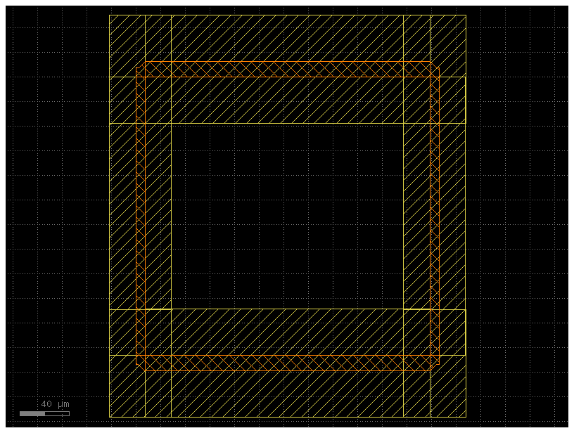

```python
blc = ihp.cells.branch_line_coupler(
    frequency=f,
    connection_length=connection_length_blc,
    signal_cross_section=signal_cross_section,
    ground_cross_section=ground_cross_section,
    Z0=Z0,
    e_r=e_r,
)
blc.plot()
```

The first branch line coupler (BLC_3) is added as a reference to the main component at the center position (0, 0).

```python
blc_3_ref = c.add_ref(blc)
```

## Corner Transition Piece

The three BLCs are placed corner to corner, which keeps the paths between them as short as possible and so minimizes conductor loss and phase mismatch. Where two BLCs meet, `tline_corner` joins their corner ports: a square TopMetal2 patch with a port on each side over an oversized Metal5 ground plate. Its side is the width of a line with `CORNER_Z_FACTOR` x $Z_0$ = 65.7 Ohm, 3.42 µm.

```
Calculated width: 3.42 um for Z0: 65.7 ohm
```

[figure not shown]

```python
corner = ihp.cells.tline_corner(
    signal_cross_section=signal_cross_section,
    ground_cross_section=ground_cross_section,
    Z0=Z0 * CORNER_Z_FACTOR,
)

corner.plot()
corner_top_ref = c.add_ref(corner)
```

The first BLC (BLC_3) is positioned at the origin (0, 0) and connects the top corner piece to its port (e1) at 45 degrees. To verify the placement, the result is plotted.

The corner square is narrower than the 7.2 µm coupler port it attaches to, which is why the width check of `connect()` is switched off with `allow_width_mismatch=True`.

[figure not shown]

```python
blc_3_ref.center = (0, 0)
corner_top_ref.connect("e1", blc_3_ref.ports["e1"], allow_width_mismatch=True)

c.plot()
```

The second branch line coupler (BLC_1) is added at the top by connecting it to the top corner pieces port (e4).

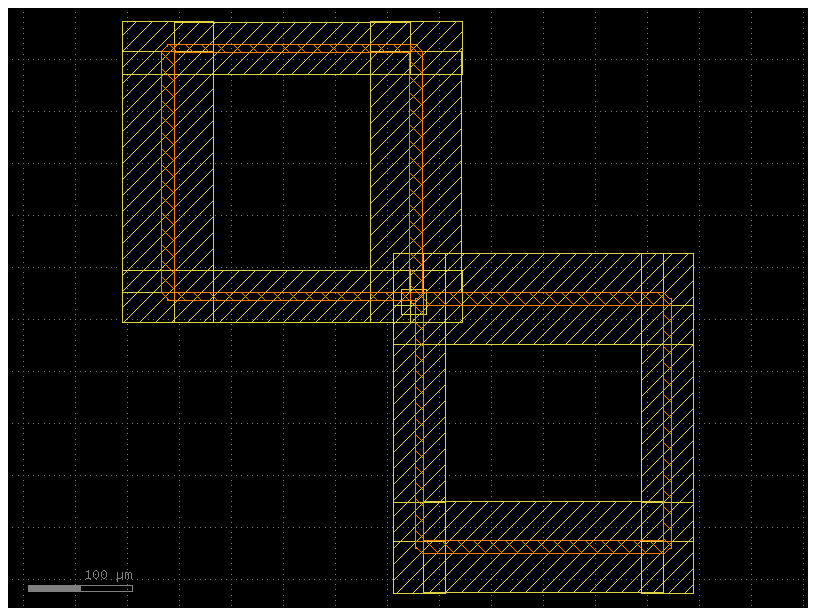

```python
blc_1_ref = c.add_ref(blc)
blc_1_ref.connect("e4", corner_top_ref.ports["e4"], allow_width_mismatch=True)

c.plot()
```

A second corner piece is added for the bottom branch, and the third BLC (BLC_2) is placed by connecting it through this corner piece to BLC_3's bottom port (e4).

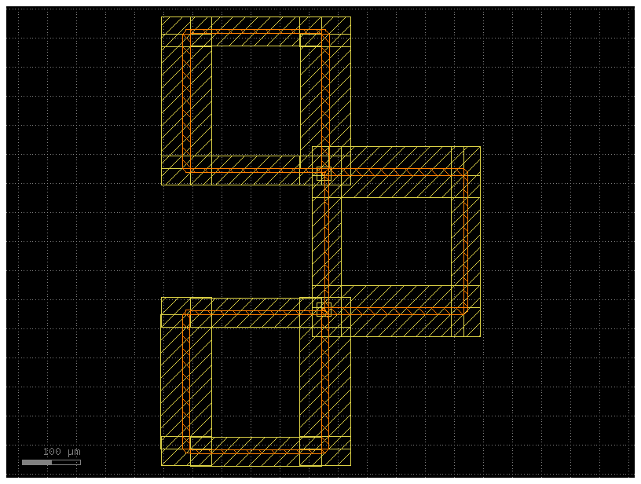

```python
corner_bot_ref = c.add_ref(corner)
corner_bot_ref.connect("e1", blc_3_ref.ports["e4"], allow_width_mismatch=True)
blc_2_ref = c.add_ref(blc)
blc_2_ref.connect("e1", corner_bot_ref.ports["e2"], allow_width_mismatch=True)

c.plot()
```

## Wilkinson Power Divider Design

Now that the three BLCs form a corner structure, the second RF device is the Wilkinson power divider (WPD). It splits the LO from the bandpass filter equally and in phase into the two paths to the top and the bottom BLC. Each arm is a $\lambda_g/4$ line with $\sqrt{2}\,Z_0$, which transforms the 50 Ohm load at its output to 100 Ohm, so that the two arms in parallel present 50 Ohm at the input.

The textbook WPD has an isolation resistor of $2Z_0$ between its outputs, which only carries current when the two outputs see different signals. Under the matched, in-phase, equal-amplitude condition of this forward-dividing path it can be omitted, and at mm-wave frequencies it has to be: a 100 Ohm resistor with its connections exceeds the $\lambda_0/10$ rule of thumb for lumped elements and would add an unintended, frequency-dependent element. The price is an output isolation of about -7 dB, close to the -6 dB of an ideal resistor-less divider, which is acceptable because both outputs see symmetric, matched loads.

The WPD is a custom cell of the add-on (`ihp.cells.wilkinson_power_divider`) and is placed in the central space between BLC_1 (top) and BLC_2 (bottom) to save area:

| WPD at 160 GHz | Value |
| --- | --- |
| arms with $\sqrt{2}\,Z_0$ = 70.7 Ohm | 2.51 µm wide, 238.8 µm long |
| input and outputs with $Z_0$ = 50 Ohm | 7.20 µm wide |
| footprint, `wpd_shape = "U"` | 174 µm x 174 µm |

The EM simulation gives an input matching below -16 dB and only 0.3 dB to 0.7 dB of excess loss above the ideal 3 dB split, and, owing to the symmetry, an amplitude and phase imbalance between the outputs within 0.02 dB and 0.1°.

The code cell generates the WPD and plots it.

```
Calculated width: 7.2 um for Z0: 50 ohm
Calculated width: 2.5100000000000002 um for Z0: 70.71 ohm
Calculated Z0: 70.75520001248569 ohm for width: 2.51 um
Calculated width: 2.5100000000000002 um for Z0: 70.71 ohm
Calculated Z0: 70.75520001248569 ohm for width: 2.51 um
```

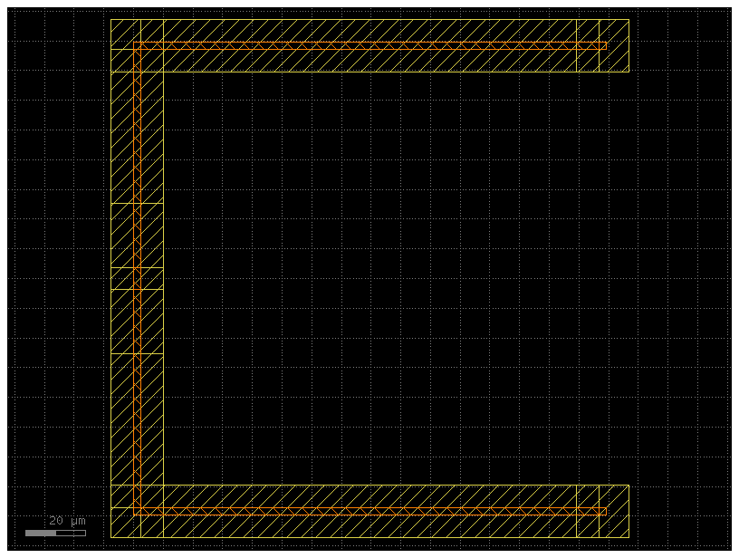

```python
wpd = ihp.cells.wilkinson_power_divider(
    frequency=f,
    connection_length=connection_length_wpd,
    signal_cross_section=signal_cross_section,
    ground_cross_section=ground_cross_section,
    Z0=Z0,
    e_r=e_r,
    shape=wpd_shape,
)

wpd.plot()
```

The input port of the WPD is rotated to face left (orientation = 0), then is added as a reference to the main component. This ensures the input transmission line connects properly from the left side.

```python
wpd.ports["e1"].orientation = 0
wpd_ref = c.add_ref(wpd)
```

## WPD-to-BLC Connections

The transmission line segments that connect the WPD outputs to the BLC ports are calculated as follows:

- Measure the vertical distance between BLC_1 and BLC_2
- Subtract the WPD height
- Divide by 2 to get the connection length for each side (top and bottom)

A single connection line segment is created, which is used for both the top and bottom connections to balance the layout.

```
Calculated width: 7.2 um for Z0: 50 ohm
```

[figure not shown]

```python
connection_length_wpd_blc_one_leg = blc_1_ref.ports["e1"].center[1] - blc_2_ref.ports["e4"].center[1] - (wpd_ref.ports["e2"].center[1] - wpd_ref.ports["e3"].center[1])

connection_wpd_blc = ihp.cells.tline(
    length=snap_to_grid(connection_length_wpd_blc_one_leg / 2) + ihp.tech.nm,  # one grid step of margin
    signal_cross_section=signal_cross_section,
    ground_cross_section=ground_cross_section,
    Z0=Z0,
)

connection_wpd_blc.plot()
```

The top leg is placed first. One end connects to port `e1` of BLC_1, the coupler above.

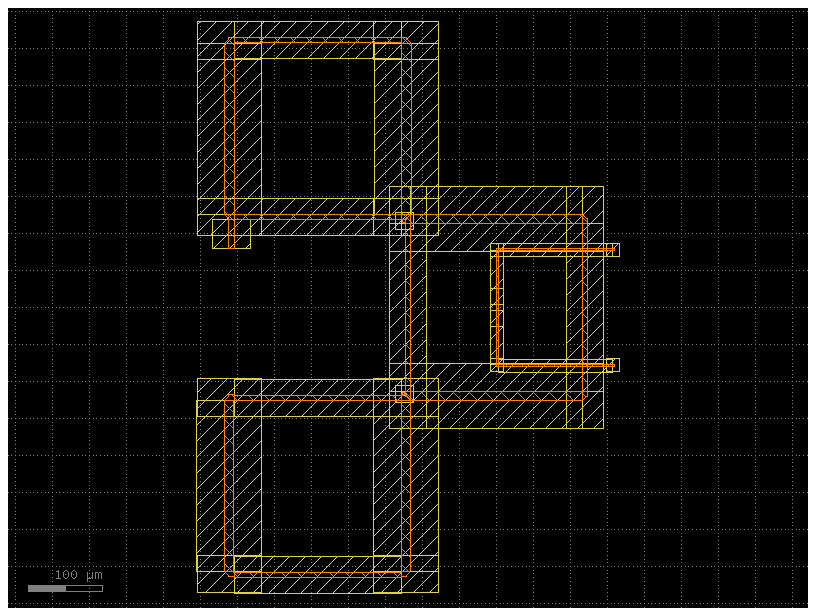

```python
connection_wpd_blc_top_ref = c.add_ref(connection_wpd_blc)
connection_wpd_blc_top_ref.connect("e1", blc_1_ref.ports["e1"])

c.plot()
```

The WPD is attached with its output `e3` to the free end of the top leg, so its position follows from the couplers instead of being set by coordinates.

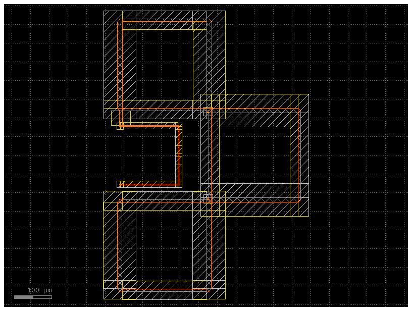

```python
wpd_ref.connect("e3", connection_wpd_blc_top_ref.ports["e2"])

c.plot()
```

The bottom leg connects port `e4` of BLC_2 to the second WPD output `e2`. Both legs are the same line, so the two LO paths from the WPD to the couplers are identical.

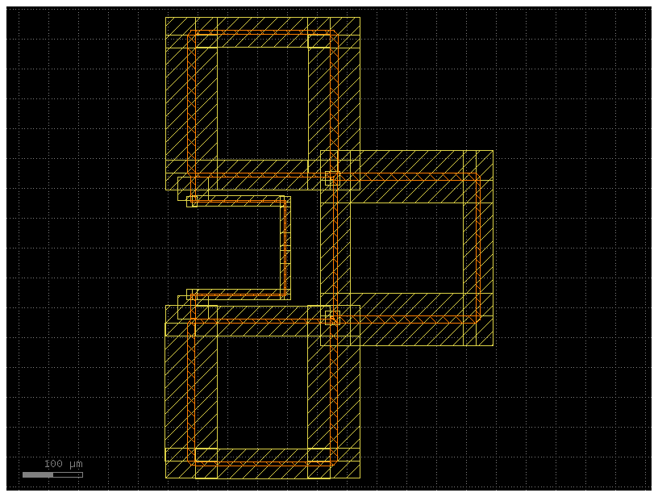

```python
connection_wpd_blc_bot_ref = c.add_ref(connection_wpd_blc)
connection_wpd_blc_bot_ref.connect("e1", blc_2_ref.ports["e4"])

wpd_ref.connect("e2", connection_wpd_blc_bot_ref.ports["e2"])

c.plot()
```

## Hairpin Coupled-Line Bandpass Filter Design

The third and last RF device is the hairpin coupled-line bandpass filter (BPF) at the LO input, which limits the LO to the band around `f`. It is a third-order Butterworth filter built from coupled $\lambda_g/4$ line sections, which are folded into hairpins for a compact layout. The BPF is a custom cell of the add-on (`ihp.cells.hairpin_coupled_line_bandpass_filter`), generated from `f`, the filter order, type, and bandwidth defined above, and connects to the WPD input through a short line:

| BPF at 160 GHz | Value |
| --- | --- |
| section length | 238.8 µm |
| footprint | 219 µm x 289 µm |

The code cell generates the BPF from the filter parameters defined above, adds it to the chip, and plots it.

```
Calculated width: 7.2 um for Z0: 50 ohm
Calculated width: 7.2 um for Z0: 50 ohm
Calculated width: 7.2 um for Z0: 50 ohm
Calculated width: 7.13 um for Z0: 50.25 ohm
Calculated Z0: 50.26863690347976 ohm for width: 7.13 um
Calculated width: 7.2 um for Z0: 50 ohm
Calculated width: 7.2 um for Z0: 50.0 ohm
Calculated Z0: 50.03094234385018 ohm for width: 7.2 um
Calculated width: 7.2 um for Z0: 50 ohm
```

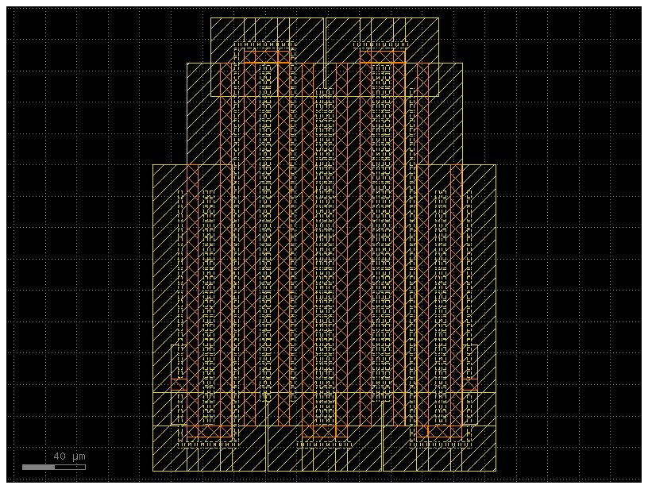

```python
bandpass_filter = ihp.cells.hairpin_coupled_line_bandpass_filter(
    frequency=f,
    bandwidth=bandwidth,
    order=order,
    filter_type=filter_type,
    ripple_dB=ripple_dB,
    connection_length=connection_length_bpf,
    signal_cross_section=signal_cross_section,
    ground_cross_section=ground_cross_section,
    Z0=Z0,
    e_r=e_r,
)

bandpass_filter_ref = c.add_ref(bandpass_filter)
bandpass_filter.plot()
```

A 50 Ohm line of `connection_length_bpf_wpd`, 0.7 x $\lambda_g/4$ or 167 µm at 160 GHz, leads from the WPD input `e1` to the left, and the BPF is attached to its end. The LO then flows from the probe pad through the filter into the WPD.

```
Calculated width: 7.2 um for Z0: 50 ohm
```

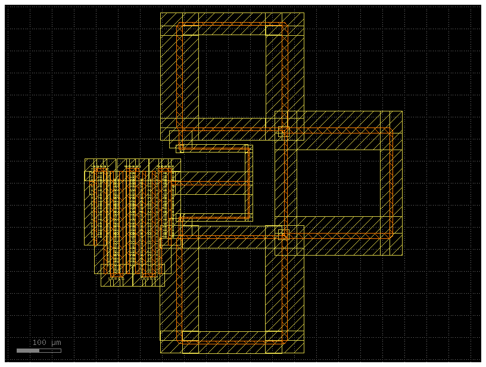

```python
connection_bpf_wpd = c.add_ref(ihp.cells.tline(
    length=connection_length_bpf_wpd,
    signal_cross_section=signal_cross_section,
    ground_cross_section=ground_cross_section,
    Z0=Z0,
))

connection_bpf_wpd.connect("e1", wpd_ref.ports["e1"])
bandpass_filter_ref.connect("e1", connection_bpf_wpd.ports["e2"])

c.plot()
```

## Termination of BLC_3

```
Calculated width: 7.2 um for Z0: 50 ohm
```

```
Six-Port-CAC: ports ['bottom', 'top'], KCell(name=via_stack_BLMetal1_TLTopMetal2_VC2_VR2_VC2_VR2_VC1_VR4, ports=['bottom', 'top'], pins=[], instances=[], locked=True, kcl=DEFAULT)
```

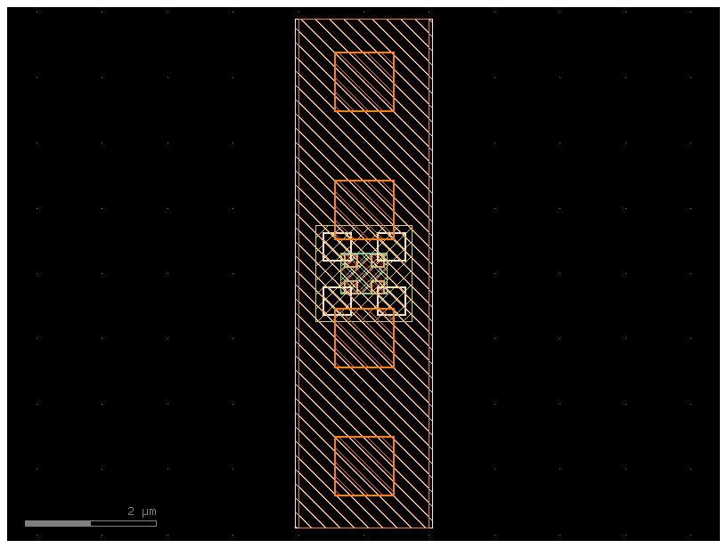

```python
connection_blc_R_termination = ihp.cells.straight(
    length=CONNECTION_LEN_TERM,
    cross_section=signal_cross_section,
    width=ihp.cells.waveguides._calculate_width_from_Z0(Z0=Z0, e_r=e_r, signal_cross_section=signal_cross_section, ground_cross_section=ground_cross_section),
)
connection_blc_R_termination_ref = c.add_ref(connection_blc_R_termination)
connection_blc_R_termination_ref.connect("e1", blc_3_ref.ports["e3"])

via_M1_TM2 = ihp.cells.via_stack(
    top_layer="TopMetal2",
    bottom_layer="Metal1",
    vn_columns=2,
    vn_rows=2,
    vt1_columns=2,
    vt1_rows=2,
    vt2_columns=1,
    vt2_rows=4,
)

via_M1_TM2.plot()
via_M1_TM2.ports["top"].orientation = 180
via_M1_TM2.ports["bottom"].orientation = 180
via_M1_TM2_ref = c.add_ref(via_M1_TM2)
via_M1_TM2_ref.connect("top", connection_blc_R_termination_ref.ports["e2"], allow_width_mismatch=True)
```

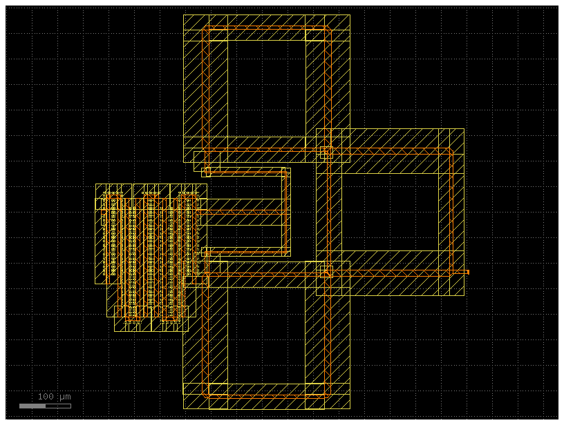

```python
c.plot()
```

The termination resistor is a silicided poly resistor (`rsil`) of 0.5 µm x 2.5 µm (`RSIL_WIDTH`, `RSIL_LENGTH`), the same device as the input termination $R_1$ of the power detector.

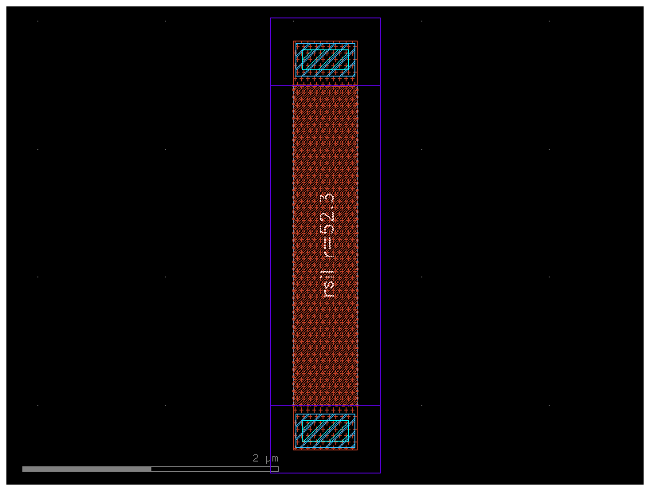

```python
R_termination = ihp.cells.rsil(
    width=RSIL_WIDTH,
    length=RSIL_LENGTH,
)
R_termination.plot()
```

The resistor is connected to the bottom of the via stack. Its other end is taken up to Metal5 through a second via stack, where a short Metal5 line joins the ground plane (VSS) that the metal fill creates later.

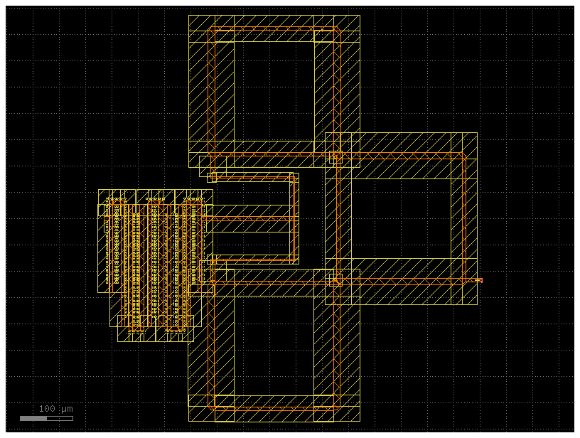

```python
R_termination_ref = c.add_ref(R_termination)
R_termination_ref.connect("e1", via_M1_TM2_ref.ports["bottom"], allow_width_mismatch=True, allow_layer_mismatch=True)

via_M1_M5 = ihp.cells.via_stack(
    top_layer="Metal5",
    bottom_layer="Metal1",
    vn_columns=2,
    vn_rows=2,
)
via_M1_M5.ports["top"].orientation = 180
via_M1_M5.ports["bottom"].orientation = 0
via_M1_M5_ref = c.add_ref(via_M1_M5)
via_M1_M5_ref.connect("bottom", R_termination_ref.ports["e2"], allow_width_mismatch=True, allow_layer_mismatch=True)

connection_R_termination_vss = ihp.cells.straight(
    length=10, # manual measurement to fit the design
    cross_section=ground_cross_section,
    width=2, # manual measurement to fit the design
)
connection_R_termination_vss_ref = c.add_ref(connection_R_termination_vss)
connection_R_termination_vss_ref.connect("e1", via_M1_M5_ref.ports["top"], allow_width_mismatch=True, allow_layer_mismatch=True)

c.plot()
```

A Metal5 no-fill rectangle, 20 µm larger than the ground connection, keeps the ground plane away from the resistor and its vias, which reduces the parasitic capacitance of the termination.

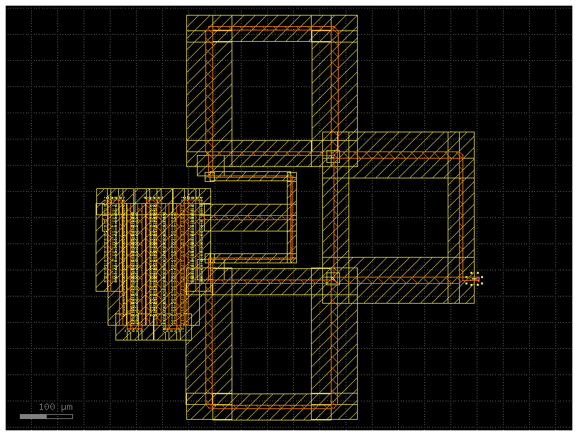

```python
# r termination metal5 nofill
c.add_ref(gf.components.rectangle(size=(connection_R_termination_vss_ref.xsize+20, connection_R_termination_vss_ref.ysize+20), layer=ihp.tech.LAYER.Metal5nofill)).center = connection_R_termination_vss_ref.center

c.plot()
```

Back at the LO path, a 30 µm long 50 Ohm line extends the free port of the BPF towards the LO probe pads, which are placed next.

```
Calculated width: 7.2 um for Z0: 50 ohm
```

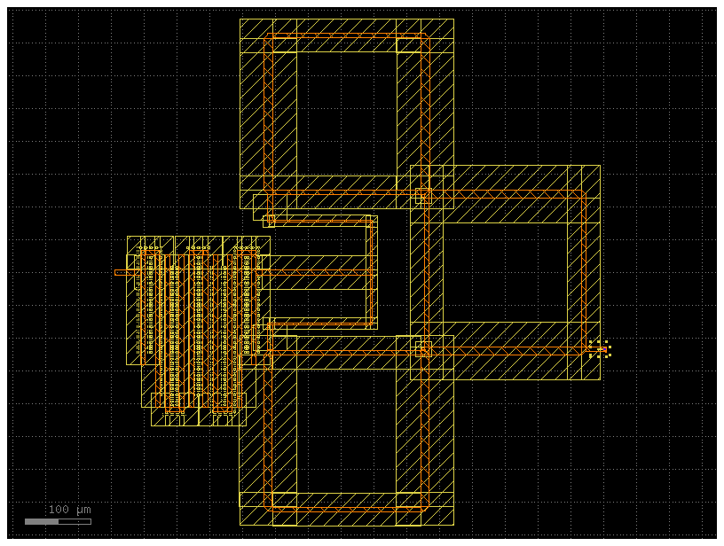

```python
connection_bpf_pad = c.add_ref(ihp.cells.straight(
    length=CONNECTION_LEN_BPF_PAD,
    cross_section=signal_cross_section,
    width=ihp.cells.waveguides._calculate_width_from_Z0(Z0=Z0, e_r=e_r, signal_cross_section=signal_cross_section, ground_cross_section=ground_cross_section),
))
connection_bpf_pad.connect("e1", bandpass_filter_ref.ports["e2"], allow_width_mismatch=True)

c.plot()
```

## Probepads for LO Input

For the external LO input signal, a GSG (Ground-Signal-Ground) probepad array on the left side is added. This probepad:

- connects to the bandpass filter input path through a transmission line.
- provides controlled 50-ohm probing interface.
- includes a Metal5 no-fill region to minimize parasitic capacitance.

The code cell creates a GSG pad array (`bondpad_array`) with a pitch of 125 µm and its ground pads tied to the substrate, rotates it by -90° into a vertical column, and connects its signal pad to the end of the line from the filter. It also adds a 105 µm square Metal5 no-fill region at the center of the array, and adds the ports of the array to the chip with the prefix `probe_left_`, which the pad labels at the end of the layout use.

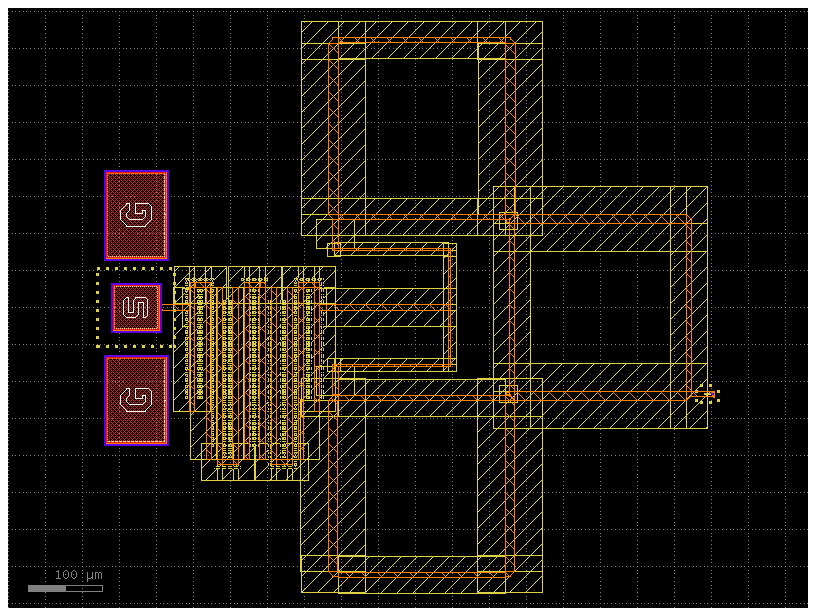

```python
probe_left = c.add_ref(ihp.cells.bondpad_array(
    config="GSG",
    pitch=PROBE_PITCH,
    width_ground=PROBE_GROUND_WIDTH,
    width_signal=PROBE_SIGNAL_SIZE,
    length_signal=PROBE_SIGNAL_SIZE,
    signal_cross_section="topmetal1_routing",
    ground_cross_section="metal1_routing",
    ground_connection="psub",
)).rotate(-90)
probe_left.center = bandpass_filter_ref.ports["e2"].center
probe_left.xmax = bandpass_filter_ref.ports["e2"].center[0] - 15
probe_left.connect("e1", connection_bpf_pad.ports["e2"], allow_width_mismatch=True)

c.add_ref(gf.components.rectangle(size=(NOFILL_GSG_SIZE, NOFILL_GSG_SIZE), layer=ihp.tech.LAYER.Metal5nofill)).center = probe_left.center
c.add_ports(probe_left.ports, prefix="probe_left_")
c.plot()
```

## Probepads for RF Input

For the external RF input signal, a GSG (Ground-Signal-Ground) probepad array on the right side is added. This probepad:

- connects to the BLC_3 through a transmission line.
- is placed at the RF input node of the six-port network.
- includes a Metal5 no-fill region to minimize parasitic capacitance.

Two 50 Ohm line pieces lead from port `e2` of BLC_3 to the right, the first three line widths long, the second `CONNECTION_LEN_BLC_PAD` + `CONNECTION_LEN_BLC_EXTRA` minus one line width. The GSG array at their end is built like the one of the LO input, with the port prefix `probe_right_`.

```
Calculated width: 7.2 um for Z0: 50 ohm
```

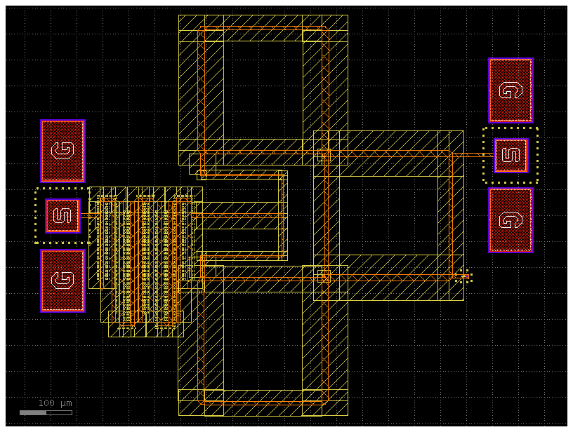

```python
width_Z0 = ihp.cells.waveguides._calculate_width_from_Z0(Z0=Z0, e_r=e_r, signal_cross_section=signal_cross_section, ground_cross_section=ground_cross_section)

connection_blc_pad_1 = c.add_ref(ihp.cells.straight(
    length=width_Z0 * 3,
    cross_section=signal_cross_section,
    width=width_Z0,
))
connection_blc_pad_1.connect("e1", blc_3_ref.ports["e2"])

connection_blc_pad_2 = c.add_ref(ihp.cells.straight(
    length=round(CONNECTION_LEN_BLC_PAD + CONNECTION_LEN_BLC_EXTRA - width_Z0, 2),
    cross_section=signal_cross_section,
    width=width_Z0,
))
connection_blc_pad_2.connect("e1", connection_blc_pad_1.ports["e2"])

# probe pads right
probe_right = c.add_ref(ihp.cells.bondpad_array(
    config="GSG",
    pitch=PROBE_PITCH,
    width_ground=PROBE_GROUND_WIDTH_RIGHT,
    width_signal=PROBE_SIGNAL_SIZE,
    length_signal=PROBE_SIGNAL_SIZE,
    signal_cross_section="topmetal1_routing",
    ground_cross_section="metal1_routing",
    ground_connection="psub",
)).rotate(-90)
probe_right.connect("e1", connection_blc_pad_2.ports["e2"], allow_width_mismatch=True)

c.add_ref(gf.components.rectangle(size=(NOFILL_GSG_SIZE, NOFILL_GSG_SIZE), layer=ihp.tech.LAYER.Metal5nofill)).center = probe_right.center
c.add_ports(probe_right.ports, prefix="probe_right_")

c.plot()
```

## RF Interconnects to the Power Detectors

The four six-port outputs (ports `e2` and `e3` of BLC_1 and BLC_2) are extended by a short straight TopMetal2 line each. Together with the `RFIN_PD` long feed line inside the power detector cell, they bridge the `RFIN_GAP` between the BLC and the detector input. The power detectors are later placed by connecting their `rfin` port to the far end of these lines.

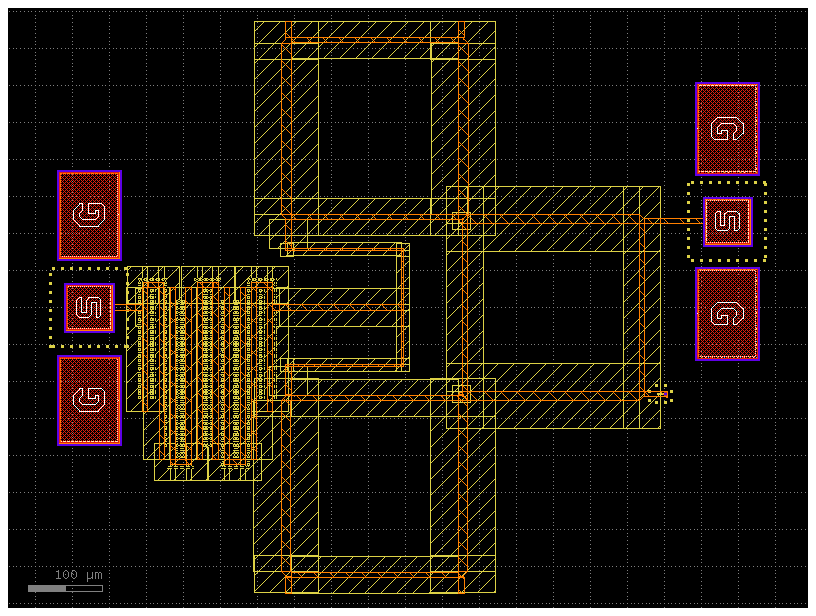

```python
rfin_connection_pd1 = c.add_ref(ihp.cells.straight(
    length=RFIN_GAP - RFIN_PD,
    cross_section=signal_cross_section,
    width=blc_1_ref.ports["e2"].width,
))
rfin_connection_pd1.connect("e1", blc_1_ref.ports["e2"])

rfin_connection_pd2 = c.add_ref(ihp.cells.straight(
    length=RFIN_GAP - RFIN_PD,
    cross_section=signal_cross_section,
    width=blc_1_ref.ports["e3"].width,
))
rfin_connection_pd2.connect("e1", blc_1_ref.ports["e3"], allow_width_mismatch=True)

rfin_connection_pd3 = c.add_ref(ihp.cells.straight(
    length=RFIN_GAP - RFIN_PD,
    cross_section=signal_cross_section,
    width=blc_2_ref.ports["e3"].width,
))
rfin_connection_pd3.connect("e1", blc_2_ref.ports["e3"], allow_width_mismatch=True)

rfin_connection_pd4 = c.add_ref(ihp.cells.straight(
    length=RFIN_GAP - RFIN_PD,
    cross_section=signal_cross_section,
    width=blc_2_ref.ports["e2"].width,
))
rfin_connection_pd4.connect("e1", blc_2_ref.ports["e2"], allow_width_mismatch=True)

c.plot()
```

## Measurement Bondpads for Power Detectors

The RF network is now completed, but the six-port outputs feed into the above-designed power detectors, which demodulate the signal for direct waveform sampling and measurements. Since we are dealing with "low" frequency signals now, we can add bondpads instead of probepads, which are then bonded to a PCB for convenient measurement setup.

The top and bottom bondpad arrays are arranged as an SSGSGSS configuration and have the following pinout: VREF, VOUT, VSS, VDD, VSS, VOUT, VREF This means that per bondpad array, two power detectors are connected. The bondpads are placed just outside the power detectors, so their distance to the six-port follows from `RFIN_GAP`, the power detector height, and `PROBE_PD_GAP`, and scales with the design frequency. Metal5 rectangles are placed around each signal bondpad to minimize parasitic capacitance.

```
┏━━━━━━┳━━━━━━━┳━━━━━━━━━━━━━┳━━━━━━━━━━━━━━━━━━━━━━━━━━┳━━━━━━━━━━━━━━━━━━━━━━━━━━━━┳━━━━━━━━━━━━┓
┃ name ┃ width ┃ orientation ┃ layer                    ┃ center                     ┃ port_type  ┃
┡━━━━━━╇━━━━━━━╇━━━━━━━━━━━━━╇━━━━━━━━━━━━━━━━━━━━━━━━━━╇━━━━━━━━━━━━━━━━━━━━━━━━━━━━╇━━━━━━━━━━━━┩
│ vout │ 0.61  │ 90.0        │ Metal4drawing (50/0)     │ (7.37, 40.84)              │ electrical │
│ vref │ 2.0   │ 90.0        │ Metal3drawing (30/0)     │ (5.47, 48.68)              │ electrical │
│ rfin │ 7.2   │ 270.0       │ TopMetal2drawing (134/0) │ (0.0, -18.400000000000002) │ electrical │
│ vss  │ 11.2  │ 90.0        │ Metal5drawing (67/0)     │ (70.32000000000001, 79.8)  │ electrical │
│ vdd  │ 10.08 │ 90.0        │ TopMetal1drawing (126/0) │ (23.44, 79.8)              │ electrical │
└──────┴───────┴─────────────┴──────────────────────────┴────────────────────────────┴────────────┘
```

```
size_nofill_x: 116.68, size_nofill_y: 103.8
```

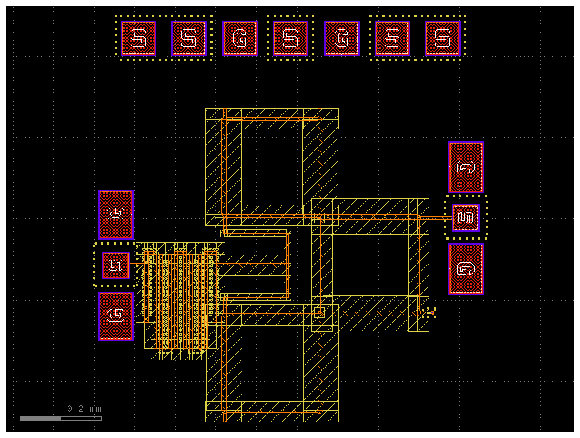

```python
# the power detector height sets the distance of the bondpads to the six-port
pd = powdet_sbd()

# snap whole chip on grid
c.xmin = 0
c.ymin = 0

# probe pads top, positioned to clear PD extent
pd_height = pd.ysize
chip_center = c.center
probe_top = c.add_ref(ihp.cells.bondpad_array(
    config="SSGSGSS",
    signal_cross_section="topmetal1_routing",
    ground_cross_section="metal1_routing",
    ground_connection="psub",
))
probe_top.center = chip_center
probe_top.ymin = snap_to_grid(blc_1_ref.ymax + RFIN_GAP / 2 + pd_height + PROBE_PD_GAP)
probe_top.xmin = snap_to_grid(probe_top.xmin)

# no fill VDD
c.add_ref(gf.components.rectangle(size=(NOFILL_VDD_SIZE, NOFILL_VDD_SIZE), layer=ihp.tech.LAYER.Metal5nofill)).center = probe_top.center
c.add_ports(probe_top.ports, prefix="probe_top_")

# no fill top
no_fill_top_left = c.add_ref(gf.components.rectangle(size=(NOFILL_SIDE_WIDTH, NOFILL_VDD_SIZE), layer=ihp.tech.LAYER.Metal5nofill))
no_fill_top_left.xmin = probe_top.xmin - NOFILL_SIDE_OFFSET
no_fill_top_left.ymin = probe_top.ymin - NOFILL_SIDE_OFFSET

no_fill_top_right = c.add_ref(gf.components.rectangle(size=(NOFILL_SIDE_WIDTH, NOFILL_VDD_SIZE), layer=ihp.tech.LAYER.Metal5nofill))
no_fill_top_right.xmax = probe_top.xmax + NOFILL_SIDE_OFFSET
no_fill_top_right.ymin = probe_top.ymin - NOFILL_SIDE_OFFSET

c.plot()
```

The bottom array is placed the same way below BLC_2, rotated by 180° so that its pads face the chip.

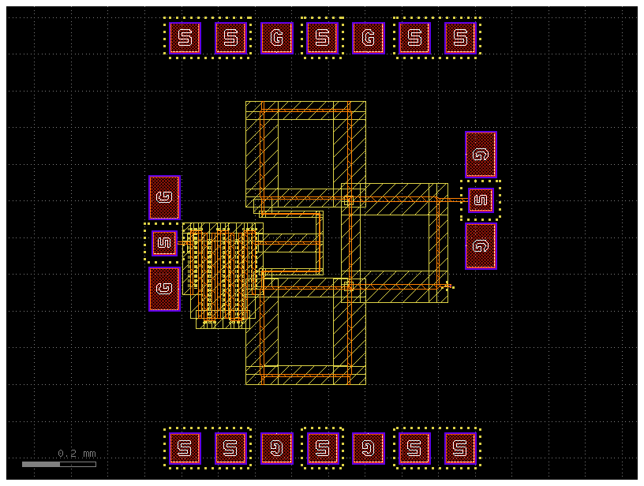

```python
# probe pads bottom
probe_bottom = c.add_ref(ihp.cells.bondpad_array(
    config="SSGSGSS",
    signal_cross_section="topmetal1_routing",
    ground_cross_section="metal1_routing",
    ground_connection="psub",
)).rotate(180)
probe_bottom.center = chip_center
probe_bottom.ymax = snap_to_grid(blc_2_ref.ymin - RFIN_GAP / 2 - pd_height - PROBE_PD_GAP)
probe_bottom.xmin = snap_to_grid(probe_bottom.xmin)

# no fill VDD
c.add_ref(gf.components.rectangle(size=(NOFILL_VDD_SIZE, NOFILL_VDD_SIZE), layer=ihp.tech.LAYER.Metal5nofill)).center = probe_bottom.center
c.add_ports(probe_bottom.ports, prefix="probe_bottom_")

# no fill bottom
no_fill_bottom_left = c.add_ref(gf.components.rectangle(size=(NOFILL_SIDE_WIDTH, NOFILL_VDD_SIZE), layer=ihp.tech.LAYER.Metal5nofill))
no_fill_bottom_left.xmin = probe_bottom.xmin - NOFILL_SIDE_OFFSET
no_fill_bottom_left.ymin = probe_bottom.ymin - NOFILL_SIDE_OFFSET

no_fill_bottom_right = c.add_ref(gf.components.rectangle(size=(NOFILL_SIDE_WIDTH, NOFILL_VDD_SIZE), layer=ihp.tech.LAYER.Metal5nofill))
no_fill_bottom_right.xmax = probe_bottom.xmax + NOFILL_SIDE_OFFSET
no_fill_bottom_right.ymin = probe_bottom.ymin - NOFILL_SIDE_OFFSET

c.plot()
```

## Instantiate Power Detector Module

The instance of the above-defined power detector module (powdet_sbd), created when placing the bondpads, is shown here. This detector will be used as the base template for all four detector channels on the chip.

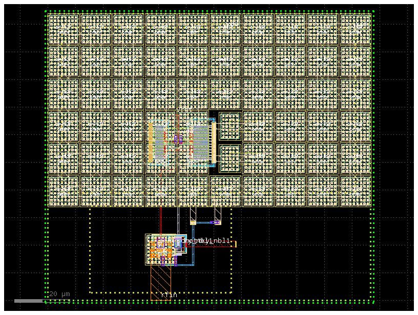

```python
pd.plot()
```

## Place and Connect First Power Detector (PD1)

PD1 is instantiated using a mirrored detector variant and is placed by connectivity:

- Take the RF interconnect line at `blc_1_ref` port `e2` (`rfin_connection_pd1`)
- Attach PD1 `rfin` to the interconnect output

This anchors the PD1 location from the RF topology and keeps placement robust to geometry changes.

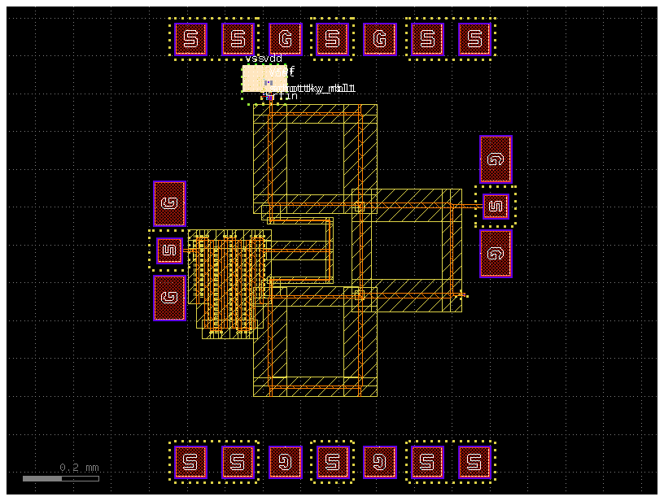

```python
pd1_ref = c.add_ref(pd).mirror_x()
pd1_ref.connect("rfin", rfin_connection_pd1.ports["e2"], allow_width_mismatch=True)
c.plot()
```

PD1 is now topology-placed via RF port connections. Next, route its supply and output nets to the top bondpads.

The first step connects PD1 `vdd` using the GDSFactory built-in electrical bundle router.

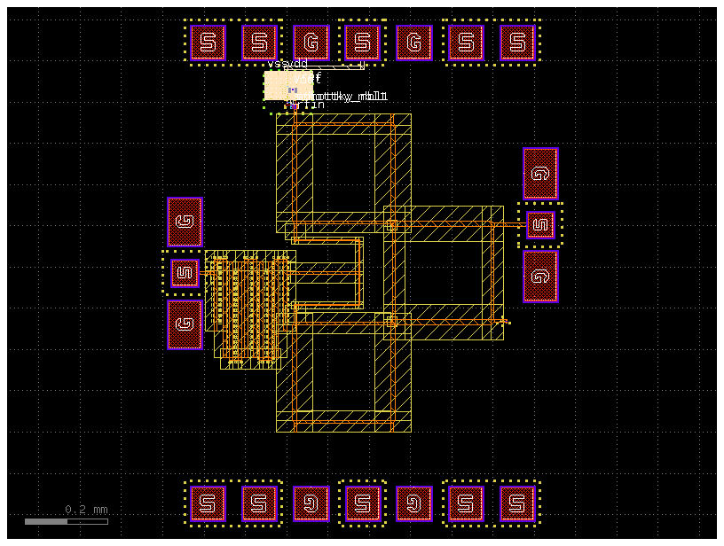

```python
route_pd1_vdd = gf.routing.route_bundle_electrical(
    component=c,
    ports1=[pd1_ref.ports["vdd"]],
    ports2=[probe_top.ports["e4"]],
    route_width=8,    # adjust for thicker connections
    layer=ihp.tech.LAYER.TopMetal1drawing,
    start_straight_length=10,
    allow_layer_mismatch=True,
    allow_width_mismatch=True,
    auto_taper=False,
    separation=0,
)
c.plot()
```

Next, PD1 `vss` is connected to the top bondpad using a Metal5 electrical route with a straight lead for clean routing.

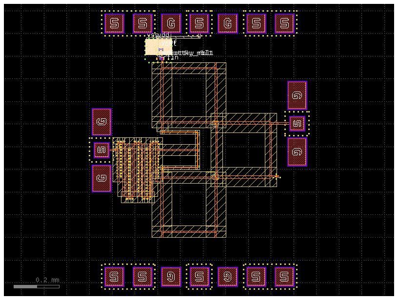

```python
route_pd1_vss = gf.routing.route_bundle_electrical(
    component=c,
    ports1=[pd1_ref.ports["vss"]],
    ports2=[probe_top.ports["e3"]],
    route_width=2,    # adjust for thicker connections
    layer=ihp.tech.LAYER.Metal5drawing,
    start_straight_length=10, # 10 or longer, to avoid routing through itself
    allow_layer_mismatch=True,
    allow_width_mismatch=True,
    auto_taper=False,
    separation=0,
)
c.plot()
```

Afterwards, PD1 `vout` is connected to the top bondpad through a Metal4 route using a TopMetal1-to-Metal4 VIA stack.

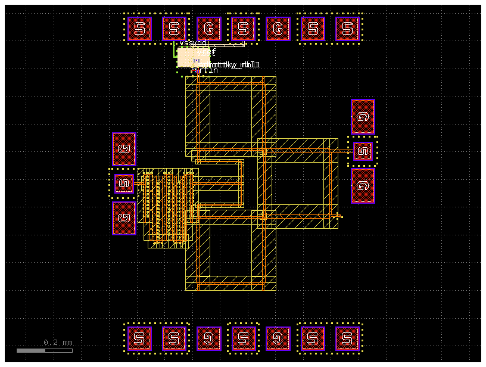

```python
via_M4_TM1 = ihp.cells.via_stack(
    top_layer="TopMetal1",
    bottom_layer="Metal4",
    vn_columns=10,
    vn_rows=3,
    vt1_columns=5,
    vt1_rows=1,
)
via_M4_TM1.ports["top"].orientation = 90
via_M4_TM1.ports["bottom"].orientation = 270
via_M4_TM1_ref = c.add_ref(via_M4_TM1)
via_M4_TM1_ref.connect("top", probe_top.ports["e2"], allow_width_mismatch=True, allow_layer_mismatch=True)
via_M4_TM1_ref.move((0, via_M4_TM1_ref.ysize/2))
route_pd1_vout = gf.routing.route_bundle_electrical(
    component=c,
    ports1=[pd1_ref.ports["vout"]],
    ports2=[via_M4_TM1_ref.ports["bottom"]],
    route_width=4,    # adjust for thicker connections
    layer=ihp.tech.LAYER.Metal4drawing,
    start_straight_length=10, # 10 or longer, to avoid routing through itself
    allow_layer_mismatch=True,
    allow_width_mismatch=True,
    auto_taper=False,
    separation=0,
)
c.plot()
```

Finally, PD1 `vref` is connected to the top bondpad through a Metal3 route using a TopMetal1-to-Metal3 VIA stack.

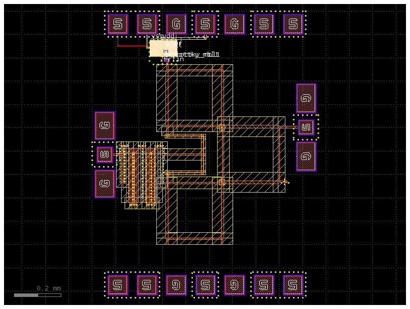

```python
via_M3_TM1 = ihp.cells.via_stack(
    top_layer="TopMetal1",
    bottom_layer="Metal3",
    vn_columns=10,
    vn_rows=3,
    vt1_columns=5,
    vt1_rows=1,
)
via_M3_TM1.ports["top"].orientation = 90
via_M3_TM1.ports["bottom"].orientation = 270
via_M3_TM1_ref = c.add_ref(via_M3_TM1)
via_M3_TM1_ref.connect("top", probe_top.ports["e1"], allow_width_mismatch=True, allow_layer_mismatch=True)
via_M3_TM1_ref.move((0, via_M3_TM1_ref.ysize/2))
route_pd1_vref = gf.routing.route_bundle_electrical(
    component=c,
    ports1=[pd1_ref.ports["vref"]],
    ports2=[via_M3_TM1_ref.ports["bottom"]],
    route_width=4,    # adjust for thicker connections
    layer=ihp.tech.LAYER.Metal3drawing,
    start_straight_length=10, # 10 or longer, to avoid routing through itself
    allow_layer_mismatch=True,
    allow_width_mismatch=True,
    auto_taper=False,
    separation=0,
)
c.plot()
```

The RF and bias routing for PD1 is completed. Next, instantiate and route PD2 using the complementary orientation and adjacent BLC branch.

## Place and Connect Second Power Detector (PD2)

PD2 is instantiated in its non-mirrored orientation and is placed by connectivity:

- Connect an RF interconnect from `blc_1_ref` port `e3` to PD2 `rfin`
- Route `vdd` and `vss` to top bondpads
- Route `vout` and `vref` through Metal4/Metal3 paths using via stacks to top bondpads

This keeps PD2 aligned with the surrounding network as dimensions scale.

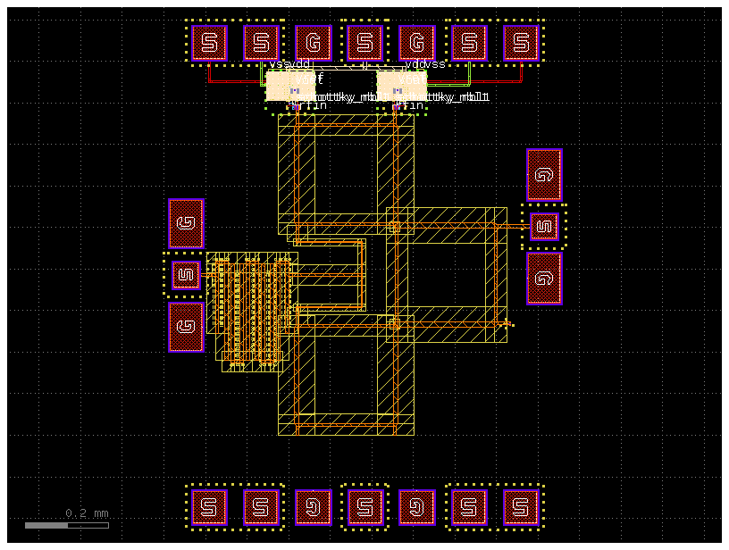

```python
pd2_ref = c.add_ref(pd)
pd2_ref.connect("rfin", rfin_connection_pd2.ports["e2"], allow_width_mismatch=True)

# vdd connection of pd2 to probe top
route_pd2_vdd = gf.routing.route_bundle_electrical(
    component=c,
    ports1=[pd2_ref.ports["vdd"]],
    ports2=[probe_top.ports["e4"]],
    route_width=8,    # adjust for thicker connections
    layer=ihp.tech.LAYER.TopMetal1drawing,
    start_straight_length=10,
    allow_layer_mismatch=True,
    allow_width_mismatch=True,
    auto_taper=False,
    separation=0,
)
# vss connection of pd2 to probe top
route_pd2_vss = gf.routing.route_bundle_electrical(
    component=c,
    ports1=[pd2_ref.ports["vss"]],
    ports2=[probe_top.ports["e5"]],
    route_width=2,    # adjust for thicker connections
    layer=ihp.tech.LAYER.Metal5drawing,
    start_straight_length=10, # 10 or longer, to avoid routing through itself
    allow_layer_mismatch=True,
    allow_width_mismatch=True,
    auto_taper=False,
    separation=0,
)
# vout connection of pd2 to probe top
via_M4_TM1_ref = c.add_ref(via_M4_TM1)
via_M4_TM1_ref.connect("top", probe_top.ports["e6"], allow_width_mismatch=True, allow_layer_mismatch=True)
via_M4_TM1_ref.move((0, via_M4_TM1_ref.ysize/2))
route_pd2_vout = gf.routing.route_bundle_electrical(
    component=c,
    ports1=[pd2_ref.ports["vout"]],
    ports2=[via_M4_TM1_ref.ports["bottom"]],
    route_width=4,    # adjust for thicker connections
    layer=ihp.tech.LAYER.Metal4drawing,
    start_straight_length=10, # 10 or longer, to avoid routing through itself
    allow_layer_mismatch=True,
    allow_width_mismatch=True,
    auto_taper=False,
    separation=0,
)
# vref connection of pd2 to probe top
via_M3_TM1_ref = c.add_ref(via_M3_TM1)
via_M3_TM1_ref.connect("top", probe_top.ports["e7"], allow_width_mismatch=True, allow_layer_mismatch=True)
via_M3_TM1_ref.move((0, via_M3_TM1_ref.ysize/2))
route_pd2_vref = gf.routing.route_bundle_electrical(
    component=c,
    ports1=[pd2_ref.ports["vref"]],
    ports2=[via_M3_TM1_ref.ports["bottom"]],
    route_width=4,    # adjust for thicker connections
    layer=ihp.tech.LAYER.Metal3drawing,
    start_straight_length=10, # 10 or longer, to avoid routing through itself
    allow_layer_mismatch=True,
    allow_width_mismatch=True,
    auto_taper=False,
    separation=0,
)

c.plot()
```

## Place and Connect Third Power Detector (PD3)

PD3 is instantiated with both mirror operations (`mirror_y().mirror_x()`), then placed through net connectivity:

- Drive `rfin` from `blc_2_ref` port `e3` through the RF interconnect
- Route `vdd`, `vss`, `vout`, and `vref` to the bottom bondpads
- Use VIA-assisted transitions for `vout` (Metal4) and `vref` (Metal3)

PD3 placement is derived from mirror transforms plus port connections, so it adapts automatically with layout changes.

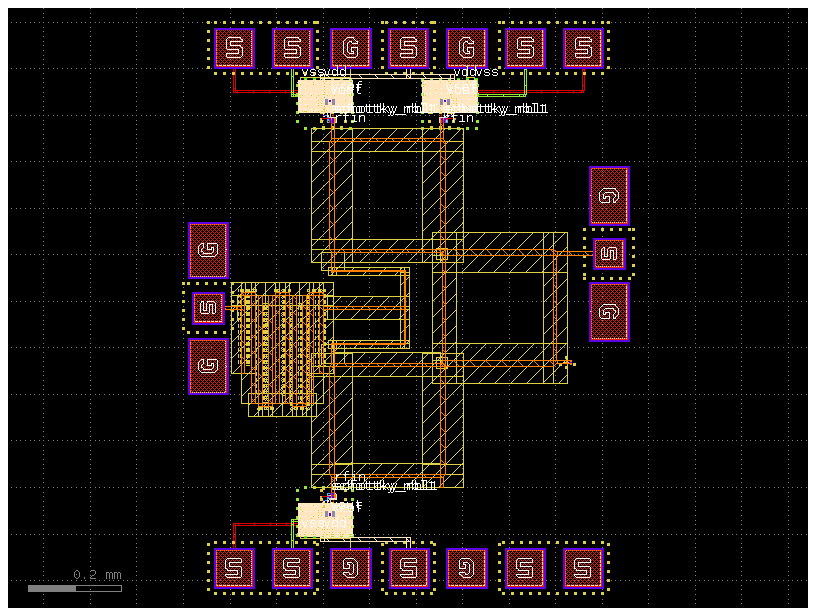

```python
pd3_ref = c.add_ref(pd).mirror_y().mirror_x()
pd3_ref.connect("rfin", rfin_connection_pd3.ports["e2"], allow_width_mismatch=True)

# vdd connection of pd3 to probe bottom
route_pd3_vdd = gf.routing.route_bundle_electrical(
    component=c,
    ports1=[pd3_ref.ports["vdd"]],
    ports2=[probe_bottom.ports["e4"]],
    route_width=8,    # adjust for thicker connections
    layer=ihp.tech.LAYER.TopMetal1drawing,
    start_straight_length=10,
    allow_layer_mismatch=True,
    allow_width_mismatch=True,
    auto_taper=False,
    separation=0,
)
# vss connection of pd3 to probe bottom
route_pd3_vss = gf.routing.route_bundle_electrical(
    component=c,
    ports1=[pd3_ref.ports["vss"]],
    ports2=[probe_bottom.ports["e5"]],
    route_width=2,    # adjust for thicker connections
    layer=ihp.tech.LAYER.Metal5drawing,
    start_straight_length=10, # 10 or longer, to avoid routing through itself
    allow_layer_mismatch=True,
    allow_width_mismatch=True,
    auto_taper=False,
    separation=0,
)
# vout connection of pd3 to probe bottom
via_M4_TM1_ref = c.add_ref(via_M4_TM1)
via_M4_TM1_ref.connect("top", probe_bottom.ports["e6"], allow_width_mismatch=True, allow_layer_mismatch=True)
via_M4_TM1_ref.move((0, -via_M4_TM1_ref.ysize/2))

route_pd3_vout = gf.routing.route_bundle_electrical(
    component=c,
    ports1=[pd3_ref.ports["vout"]],
    ports2=[via_M4_TM1_ref.ports["bottom"]],
    route_width=4,    # adjust for thicker connections
    layer=ihp.tech.LAYER.Metal4drawing,
    start_straight_length=10, # 10 or longer, to avoid routing through itself
    allow_layer_mismatch=True,
    allow_width_mismatch=True,
    auto_taper=False,
    separation=0,
)
# vref connection of pd3 to probe bottom
via_M3_TM1_ref = c.add_ref(via_M3_TM1)
via_M3_TM1_ref.connect("top", probe_bottom.ports["e7"], allow_width_mismatch=True, allow_layer_mismatch=True)
via_M3_TM1_ref.move((0, -via_M3_TM1_ref.ysize/2))
route_pd3_vref = gf.routing.route_bundle_electrical(
    component=c,
    ports1=[pd3_ref.ports["vref"]],
    ports2=[via_M3_TM1_ref.ports["bottom"]],
    route_width=4,    # adjust for thicker connections
    layer=ihp.tech.LAYER.Metal3drawing,
    start_straight_length=10, # 10 or longer, to avoid routing through itself
    allow_layer_mismatch=True,
    allow_width_mismatch=True,
    auto_taper=False,
    separation=0,
)
c.plot()
```